# Bee analysis test

Eddy Dowle

2025-05-15

## Geomorph

Using Geomorph package to do a generalized procrustes analysis on the TPS file and run basic statistics/plots. Not very familiar with the package so Im only using a very small subset of it and Im not convinced that I have everything correct/done in the best way (its been 15 years since I did this).

```r
#bring in TPS file
bees<-readland.tps('C:/Users/hrlexd/Dropbox/PlantAndFood (1)/NativeBees/Bee_pictures/Forewing_file_tps_dig_15_05_2025_1_renamed.TPS',specID = 'imageID')
```

```
##
## No curves detected; all points appear to be fixed landmarks.
```

```r
#col_bees<-read.csv('C:/Users/hrlexd/Dropbox/PlantAndFood (1)/NativeBees/Bee_pictures/bee_colours.csv')
#generate a file of species names for each sample etc for plotting
Sample_names<-labels(bees)[[3]]
#Sample_names<-gsub('.*\\\\','',Sample_names)
species_list<-gsub('_.*','',Sample_names)
#species_list<-gsub('L.Kanap','L.kanap',species_list)
unique(species_list)
```

```
## [1] "L.bolt"   "L.mont"   "L.fulv"   "L.huak"   "L.imat"   "L.kanap"  "L.paahua"
## [8] "L.pango"  "Vest"
```

```r
#do a generalixed procrustes analysis on TPS
beesgpa<-gpagen(bees)
```

```
##
## Performing GPA
##   |                                                                              |                                                                      |   0%  |                                                                              |==================                                       …
##
## Making projections... Finished!
```

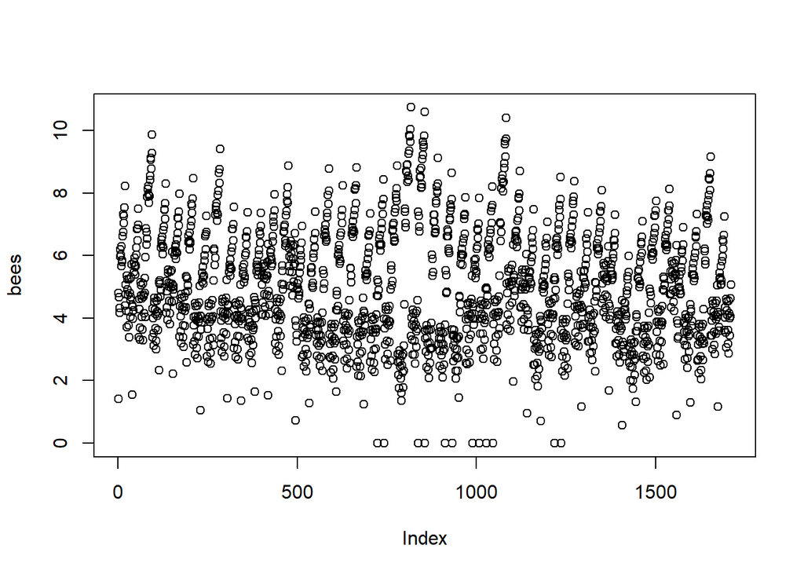

```r
#checking procrustes fit
#plot before procrustes
plot(bees)
```

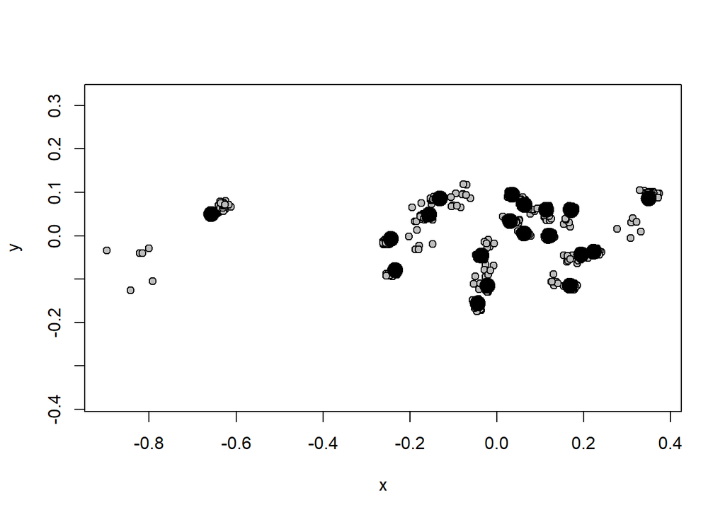

```r
#plot after procrustes
plot(beesgpa)
```

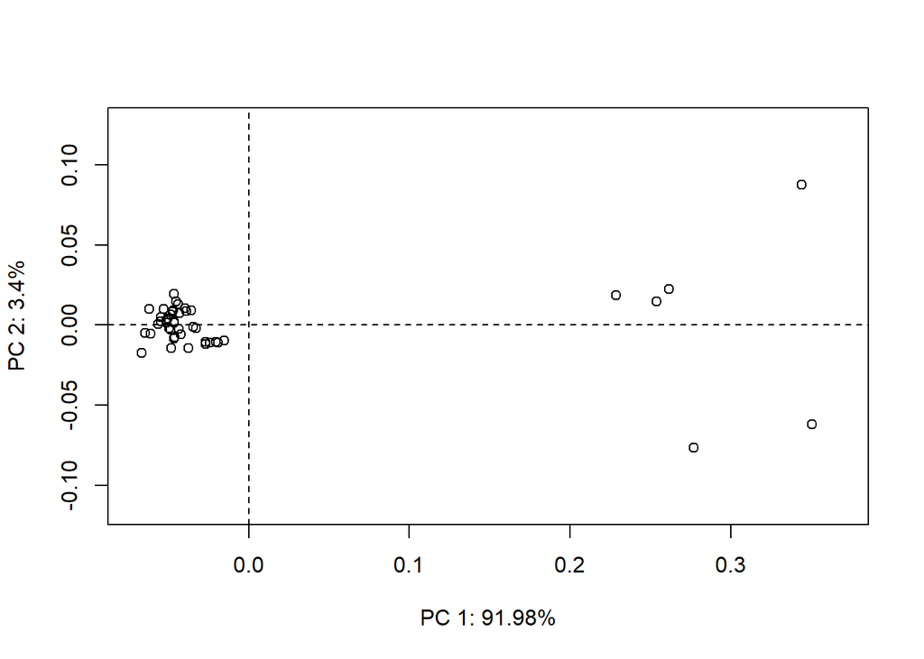

```r
#the first point looks very dodgy
PCA<-gm.prcomp(beesgpa$coords)
plot(PCA)
```

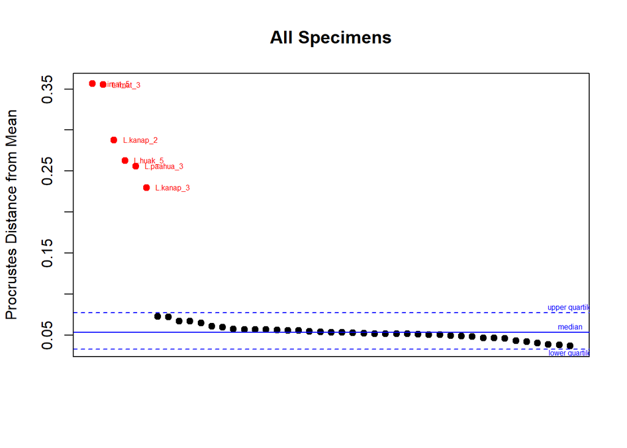

```
##   L.imat_5   L.imat_3  L.kanap_2   L.huak_5 L.paahua_3  L.kanap_3  L.pango_4
##         25         23         27         20         33         28         39
##   L.mont_5   L.huak_3  L.pango_5   L.mont_1     Vest_5   L.bolt_1   L.huak_4
##          6         18         40          2         45          7         19
##  L.pango_3     Vest_2   L.imat_1   L.huak_2   L.mont_3     Vest_3   L.mont_4
##         38         42         21         17          4         43          5
##   L.bolt_4  L.kanap_1     Vest_1   L.bolt_3  L.pango_2     Vest_4   L.imat_2
##          1         26         41          9         37         44         22
##   L.bolt_5   L.mont_2 L.paahua_1  L.kanap_5  L.pango_1   L.huak_1  L.kanap_4
##         10          3         31         30         36         16         29
## L.paahua_5   L.imat_4   L.bolt_2 L.paahua_2 L.paahua_4   L.fulv_4   L.fulv_5
##         35         24          8         32         34         14         15
##   L.fulv_3   L.fulv_2   L.fulv_1
##         13         12         11
```

```r
#thats all just those varable ones on the first point
plotOutliers(beesgpa$coords)
```

## Dropping first point

That first point just isnt stable so think we can drop it form now on.

```r
bees_removefirst <- bees[-1,,]
beesgpa<-gpagen(bees_removefirst)
```

```
##
## Performing GPA
##   |                                                                              |                                                                      |   0%  |                                                                              |==================                                       …
##
## Making projections... Finished!
```

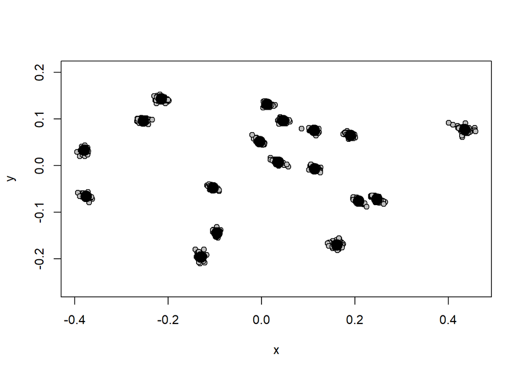

```r
#looks more stable
plot(beesgpa)
```

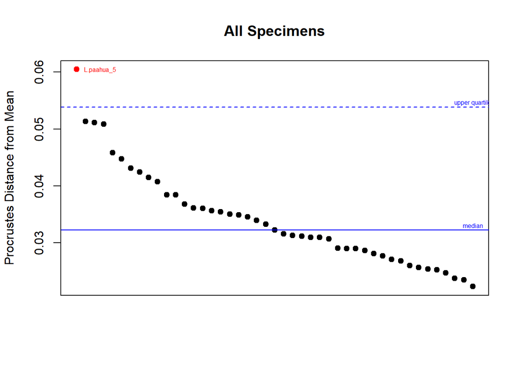

```
## L.paahua_5  L.pango_5 L.paahua_1 L.paahua_3   L.fulv_5  L.pango_4  L.pango_3
##         35         40         31         33         15         39         38
##     Vest_2   L.fulv_2   L.fulv_4  L.pango_2  L.kanap_5   L.imat_1  L.kanap_4
##         42         12         14         37         30         21         29
##  L.kanap_1 L.paahua_2   L.fulv_3     Vest_5  L.kanap_3   L.fulv_1 L.paahua_4
##         26         32         13         45         28         11         34
##   L.imat_3   L.imat_5   L.mont_4   L.huak_3   L.imat_4  L.kanap_2   L.mont_3
##         23         25          5         18         24         27          4
##   L.huak_1     Vest_4   L.huak_2   L.imat_2     Vest_3   L.mont_5   L.huak_5
##         16         44         17         22         43          6         20
##   L.mont_2   L.mont_1  L.pango_1   L.bolt_5   L.bolt_1   L.huak_4     Vest_1
##          3          2         36         10          7         19         41
##   L.bolt_2   L.bolt_4   L.bolt_3
##          8          1          9
```

```r
#plot outliers
plotOutliers(beesgpa$coords)
```

```r
#run PCA analysis
PCA<-gm.prcomp(beesgpa$coords)
#plot(PCA)
#plot with legend
PCaxis<-as.data.frame(PCA$x[,1:2])
PCaxis<-rownames_to_column(PCaxis,var='ID')
PCaxis$bee_species<-gsub('_.*','',PCaxis$ID)

#set colours
col<-as.character(c("dodgerblue2","tan1","gold1","springgreen4","orchid4","palegreen","firebrick1","cyan1","hotpink"))
names(col)<-as.character(unique(PCaxis$bee_species))
col
```

```
##         L.bolt         L.mont         L.fulv         L.huak         L.imat
##  "dodgerblue2"         "tan1"        "gold1" "springgreen4"      "orchid4"
##        L.kanap       L.paahua        L.pango           Vest
##    "palegreen"   "firebrick1"        "cyan1"      "hotpink"
```

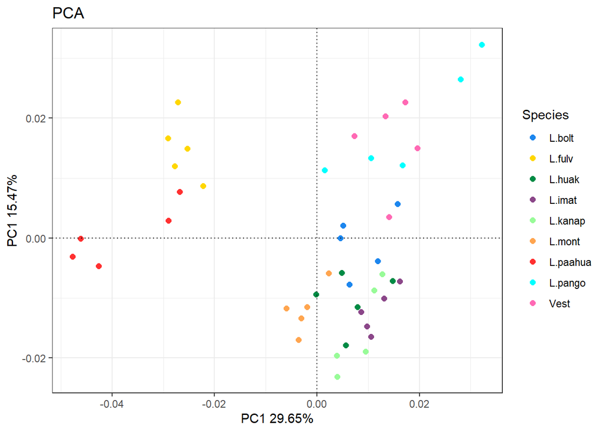

```r
#extract PC % from sdev
PC1_per<-round(as.data.frame(PCA$sdev^2/sum(PCA$sdev^2))[1,1]*100,digits=2)
PC2_per<-round(as.data.frame(PCA$sdev^2/sum(PCA$sdev^2))[2,1]*100,digits=2)
#plot
ggplot(PCaxis,aes(x=Comp1,y=Comp2,colour = bee_species))+
  geom_point(size=2)+
  theme_bw()+
  scale_color_manual(values=col)+
  labs(colour='Species',x=paste0('PC1 ',PC1_per,'%'),y=paste0('PC1 ',PC2_per,'%'),title="PCA")+
  geom_hline(yintercept=0, linetype='dotted', col = 'black')+
  geom_vline(xintercept=0, linetype='dotted', col = 'black')
```

```r
#
```

## Within Leioproctus Leioproctus

Just wanted to have a quick look just within leioproctus leiopructus as I notice on the PCA most of the variaiton is just between Neso species and Leio species

```r
#just looking with in leioproctus (plus monticola)
#fulvesencs and paahua are quite different
#redo procrustes just with Leioproctus leioproctus species (plus monitola)
bees_leioproctus <- bees[,,-c(11:15,31:35)]
bees_leioproctus <- bees_leioproctus[-1,,]
beesgpa_leio<-gpagen(bees_leioproctus)
```

```
##
## Performing GPA
##   |                                                                              |                                                                      |   0%  |                                                                              |==================                                       …
##
## Making projections... Finished!
```

```r
Sample_names_leio<-labels(bees_leioproctus)[[3]]
Sample_names_leio<-gsub('.*\\\\','',Sample_names_leio)
species_list_leio<-gsub('_.*','',Sample_names_leio)
species_list_leio<-gsub('L.Kanap','L.kanap',species_list_leio)

unique(species_list_leio)
```

```
## [1] "L.bolt"  "L.mont"  "L.huak"  "L.imat"  "L.kanap" "L.pango" "Vest"
```

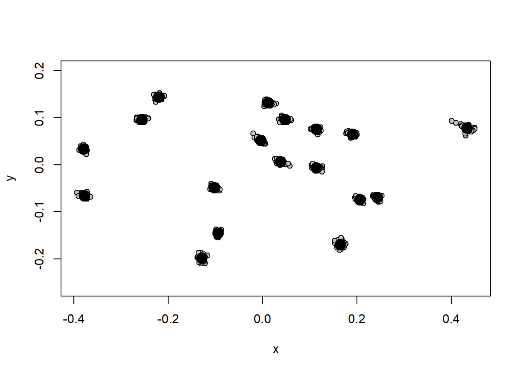

```r
plot(beesgpa_leio)
```

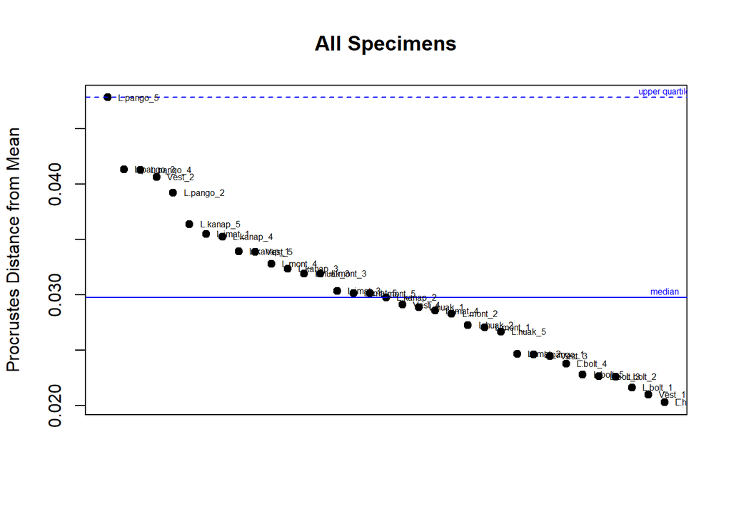

```
## L.pango_5 L.pango_3 L.pango_4    Vest_2 L.pango_2 L.kanap_5  L.imat_1 L.kanap_4
##        30        28        29        32        27        25        16        24
## L.kanap_1    Vest_5  L.mont_4 L.kanap_3  L.huak_3  L.mont_3  L.imat_3  L.imat_5
##        21        35         5        23        13         4        18        20
##  L.mont_5 L.kanap_2    Vest_4  L.huak_1  L.imat_4  L.mont_2  L.huak_2  L.mont_1
##         6        22        34        11        19         3        12         2
##  L.huak_5  L.imat_2 L.pango_1    Vest_3  L.bolt_4  L.bolt_5  L.bolt_3  L.bolt_2
##        15        17        26        33         1        10         9         8
##  L.bolt_1    Vest_1  L.huak_4
##         7        31        14
```

```r
#plot outliers
plotOutliers(beesgpa_leio$coords)
```

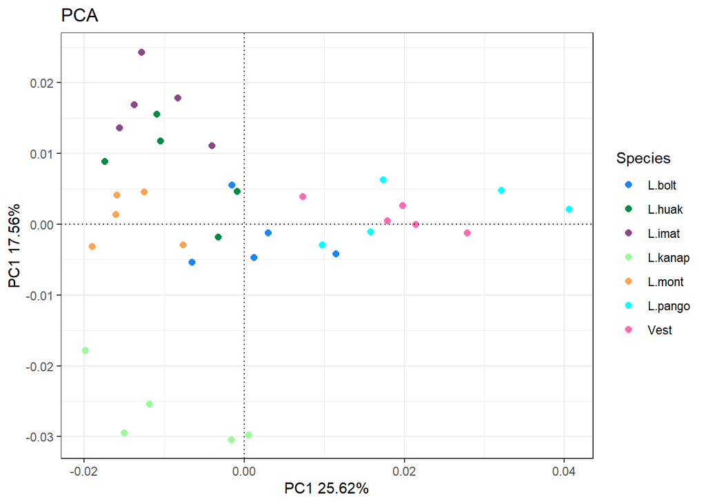

```r
#run PCA analysis
PCA<-gm.prcomp(beesgpa_leio$coords)
#summary(PCA)
#plot(PCA)
#plot with legend
PCaxis<-as.data.frame(PCA$x[,1:2])
PCaxis<-rownames_to_column(PCaxis,var='ID')
PCaxis$bee_species<-gsub('_.*','',PCaxis$ID)

PC1_per<-round(as.data.frame(PCA$sdev^2/sum(PCA$sdev^2))[1,1]*100,digits=2)
PC2_per<-round(as.data.frame(PCA$sdev^2/sum(PCA$sdev^2))[2,1]*100,digits=2)

ggplot(PCaxis,aes(x=Comp1,y=Comp2,colour = bee_species))+
  geom_point(size=2)+
  theme_bw()+
  scale_color_manual(values=col)+
  labs(colour='Species',x=paste0('PC1 ',PC1_per,'%'),y=paste0('PC1 ',PC2_per,'%'),title="PCA")+
  geom_hline(yintercept=0, linetype='dotted', col = 'black')+
  geom_vline(xintercept=0, linetype='dotted', col = 'black')
```

```r
#
```

## Shape variation

Just plotting out the shape shift of each species

```r
#shape change species compared to average
ref<-mshape(beesgpa$coords)
species_list
```

```
##  [1] "L.bolt"   "L.mont"   "L.mont"   "L.mont"   "L.mont"   "L.mont"
##  [7] "L.bolt"   "L.bolt"   "L.bolt"   "L.bolt"   "L.fulv"   "L.fulv"
## [13] "L.fulv"   "L.fulv"   "L.fulv"   "L.huak"   "L.huak"   "L.huak"
## [19] "L.huak"   "L.huak"   "L.imat"   "L.imat"   "L.imat"   "L.imat"
## [25] "L.imat"   "L.kanap"  "L.kanap"  "L.kanap"  "L.kanap"  "L.kanap"
## [31] "L.paahua" "L.paahua" "L.paahua" "L.paahua" "L.paahua" "L.pango"
## [37] "L.pango"  "L.pango"  "L.pango"  "L.pango"  "Vest"     "Vest"
## [43] "Vest"     "Vest"     "Vest"
```

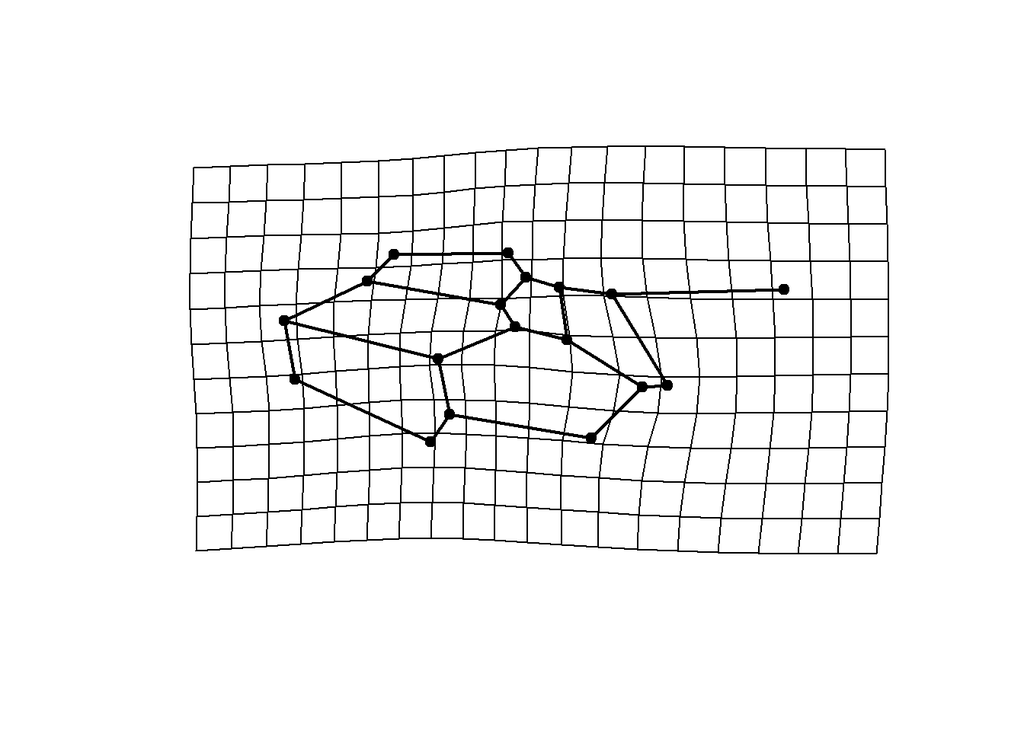

```r
#bring in links file for plotting
bee_links<-read.table('C:/Users/hrlexd/Dropbox/PlantAndFood (1)/NativeBees/Bee_pictures/Sam_april/Forewing/links_all_landmarks_remove1_sam.txt',sep=',',header=F)

#nesocoletes (note average is average across all Leioproctus sp. just grouped for veiwing)
#paahua
gpl.mn<-mshape(beesgpa$coords[,,31:35])
#plotRefToTarget(M1=ref,M2=gpl.mn,mag=2)
plotRefToTarget(M1=ref,M2=gpl.mn,mag=2,links=bee_links)
```

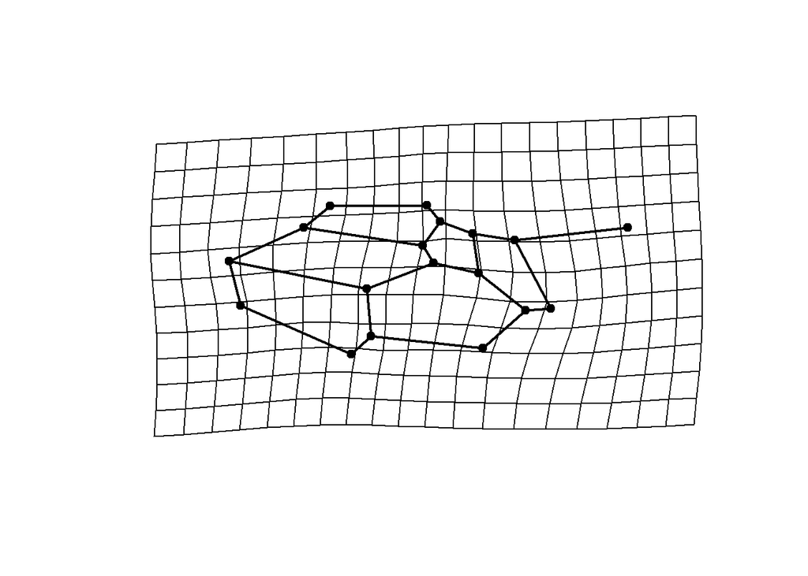

```r
#fulv
gpl.mn<-mshape(beesgpa$coords[,,c(11:15)])
#plotRefToTarget(M1=ref,M2=gpl.mn,mag=2)
plotRefToTarget(M1=ref,M2=gpl.mn,mag=2,links=bee_links)
```

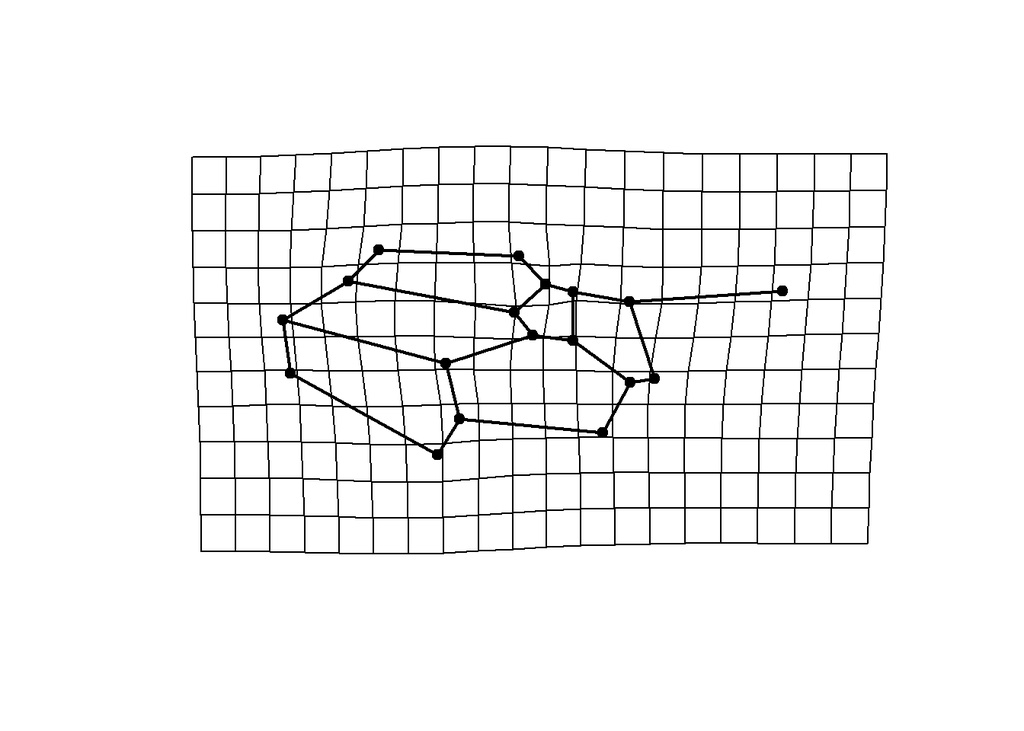

```r
#leioproctus leioproctus
#mont
gpl.mn<-mshape(beesgpa$coords[,,2:6])
#plotRefToTarget(M1=ref,M2=gpl.mn,mag=2)
plotRefToTarget(M1=ref,M2=gpl.mn,mag=2,links=bee_links)
```

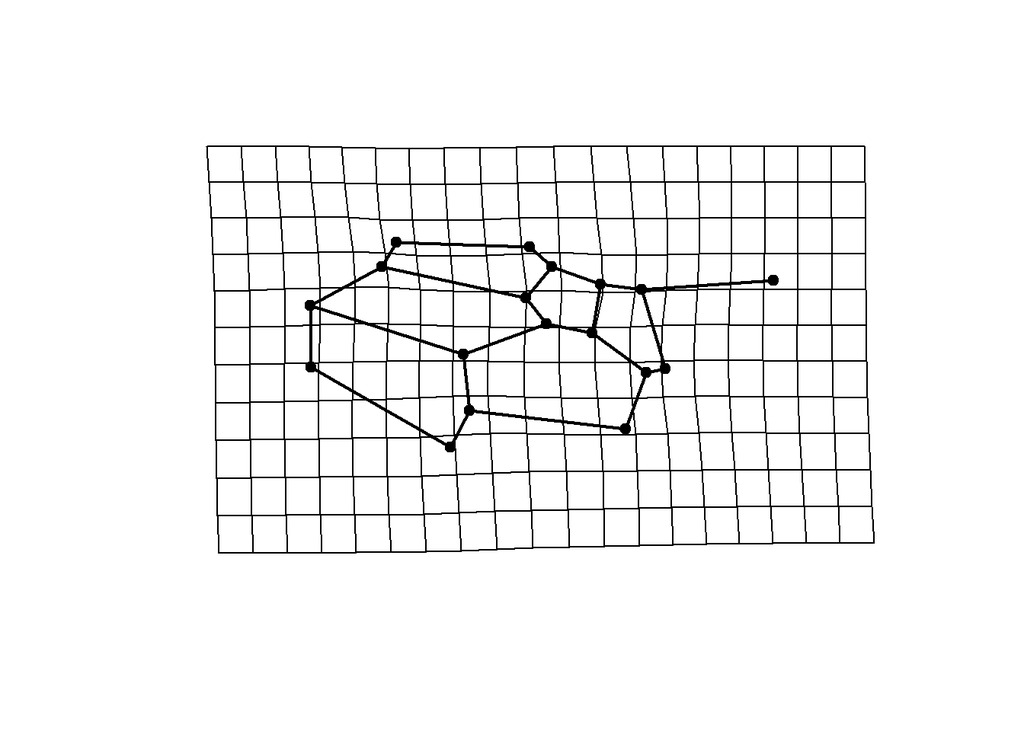

```r
#bolt
gpl.mn<-mshape(beesgpa$coords[,,c(1,7:10)])
#plotRefToTarget(M1=ref,M2=gpl.mn,mag=2)
plotRefToTarget(M1=ref,M2=gpl.mn,mag=2,links=bee_links)
```

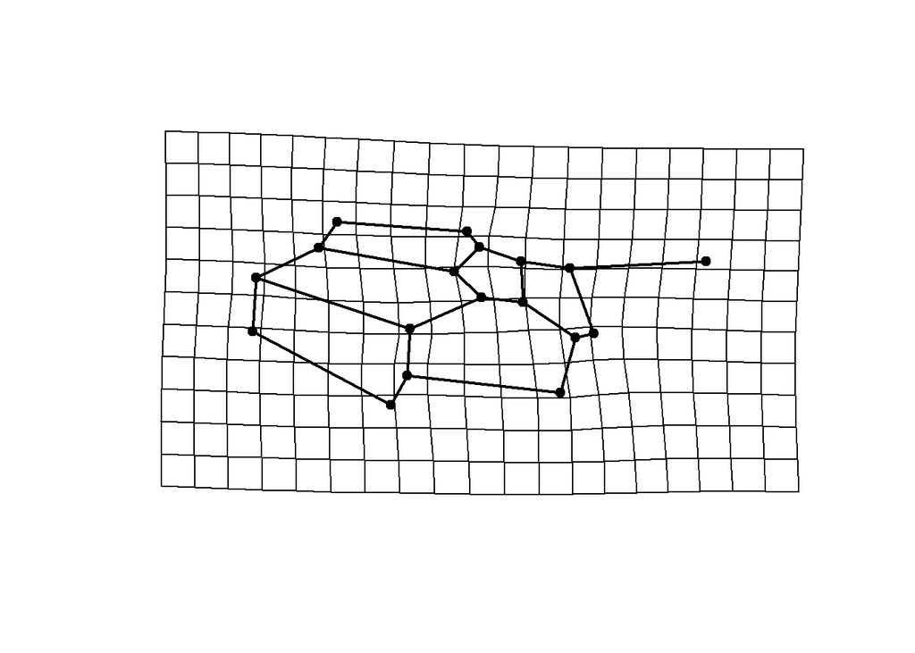

```r
#huakiwi
gpl.mn<-mshape(beesgpa$coords[,,16:20])
#plotRefToTarget(M1=ref,M2=gpl.mn,mag=2)
plotRefToTarget(M1=ref,M2=gpl.mn,mag=2,links=bee_links)
```

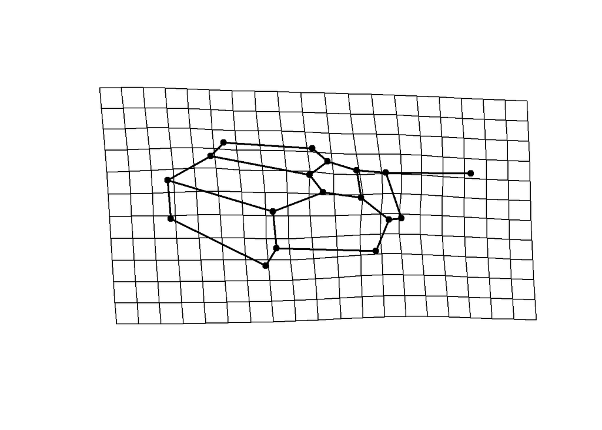

```r
#imat
gpl.mn<-mshape(beesgpa$coords[,,21:25])
#plotRefToTarget(M1=ref,M2=gpl.mn,mag=2)
plotRefToTarget(M1=ref,M2=gpl.mn,mag=2,links=bee_links)
```

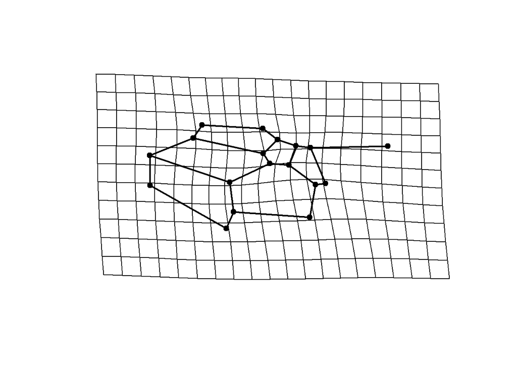

```r
#kanap
gpl.mn<-mshape(beesgpa$coords[,,26:30])
#plotRefToTarget(M1=ref,M2=gpl.mn,mag=2)
plotRefToTarget(M1=ref,M2=gpl.mn,mag=2,links=bee_links)
```

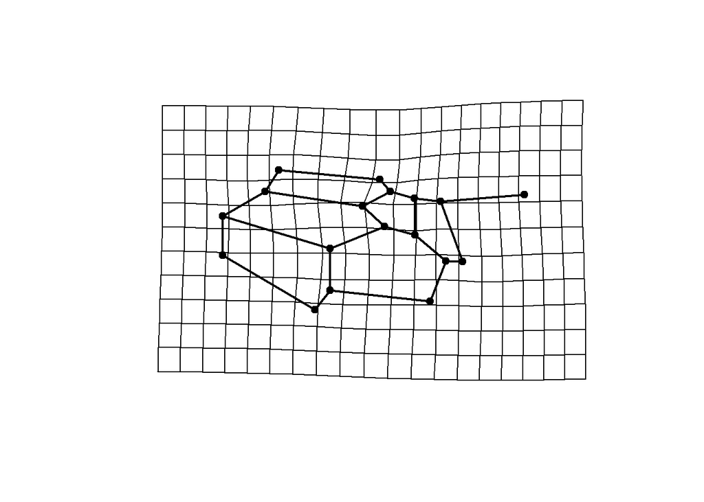

```r
#pango
gpl.mn<-mshape(beesgpa$coords[,,36:40])
#plotRefToTarget(M1=ref,M2=gpl.mn,mag=2)
plotRefToTarget(M1=ref,M2=gpl.mn,mag=2,links=bee_links)
```

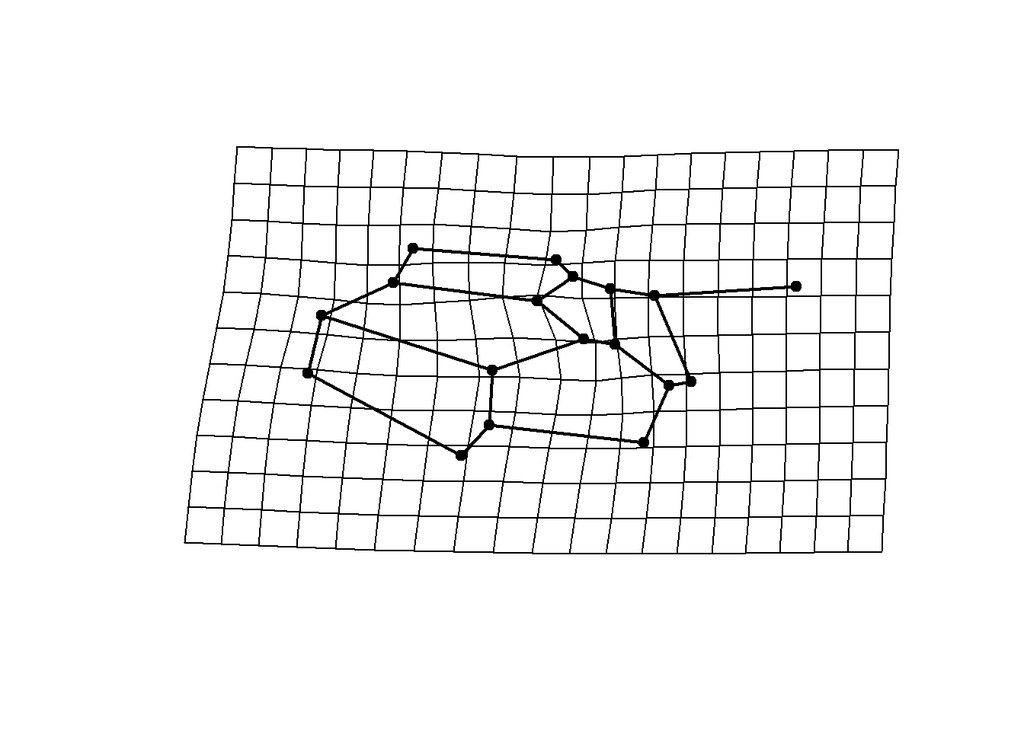

```r
#vest
gpl.mn<-mshape(beesgpa$coords[,,41:45])
#plotRefToTarget(M1=ref,M2=gpl.mn,mag=2)
plotRefToTarget(M1=ref,M2=gpl.mn,mag=2,links=bee_links)
```

```r
#
```

## Running some tests

Im not familar with geomorph so this is largely taken from the tutorial online

## Relationship between size and shape

```r
#check if there is a relationship between size and shape
#just having a look at raw csize
#kanap seem largest in general for forewing
size<-as.data.frame(beesgpa$Csize)
arrange(size,desc(size$`beesgpa$Csize`)) #%>% print(n=nrow(.))
```

```
##            beesgpa$Csize
## L.kanap_4       5.451628
## L.bolt_4        5.401636
## L.kanap_3       5.338963
## L.kanap_1       5.325175
## L.kanap_5       5.277201
## L.bolt_1        5.251831
## L.huak_2        5.195001
## L.kanap_2       5.191211
## L.huak_3        5.156144
## L.mont_1        5.099885
## L.bolt_2        5.094943
## L.fulv_2        5.090562
## L.huak_1        5.076675
## L.huak_5        5.067888
## L.paahua_2      5.065402
## L.fulv_3        5.044910
## L.bolt_3        5.031568
## L.paahua_3      5.014506
## L.paahua_1      5.014130
## L.huak_4        4.998159
## L.imat_2        4.990256
## Vest_5          4.932109
## L.mont_5        4.898149
## L.fulv_4        4.896337
## Vest_3          4.885547
## L.mont_3        4.850969
## L.imat_3        4.847321
## L.paahua_4      4.836817
## L.imat_1        4.831496
## L.pango_5       4.818466
## L.pango_4       4.806739
## Vest_2          4.764802
## L.bolt_5        4.754464
## Vest_4          4.743233
## L.imat_5        4.738130
## L.pango_1       4.718574
## L.imat_4        4.711557
## L.mont_2        4.707089
## L.paahua_5      4.681374
## L.mont_4        4.663466
## L.fulv_1        4.655944
## L.fulv_5        4.641040
## L.pango_2       4.456722
## Vest_1          4.446673
## L.pango_3       4.307219
```

```r
gdf<-geomorph.data.frame(beesgpa,species=species_list)
fit.size<-procD.lm(coords~log(Csize), data = gdf, print.progress=F)
summary(fit.size)
```

```
##
## Analysis of Variance, using Residual Randomization
## Permutation procedure: Randomization of null model residuals
## Number of permutations: 1000
## Estimation method: Ordinary Least Squares
## Sums of Squares and Cross-products: Type I
## Effect sizes (Z) based on F distributions
##
##            Df       SS        MS     Rsq      F      Z Pr(>F)
## log(Csize)  1 0.003258 0.0032580 0.05821 2.6576 2.4405  0.007 **
## Residuals  43 0.052714 0.0012259 0.94179
## Total      44 0.055972
## ---
## Signif. codes:  0 '***' 0.001 '**' 0.01 '*' 0.05 '.' 0.1 ' ' 1
##
## Call: procD.lm(f1 = coords ~ log(Csize), data = gdf, print.progress = F)
```

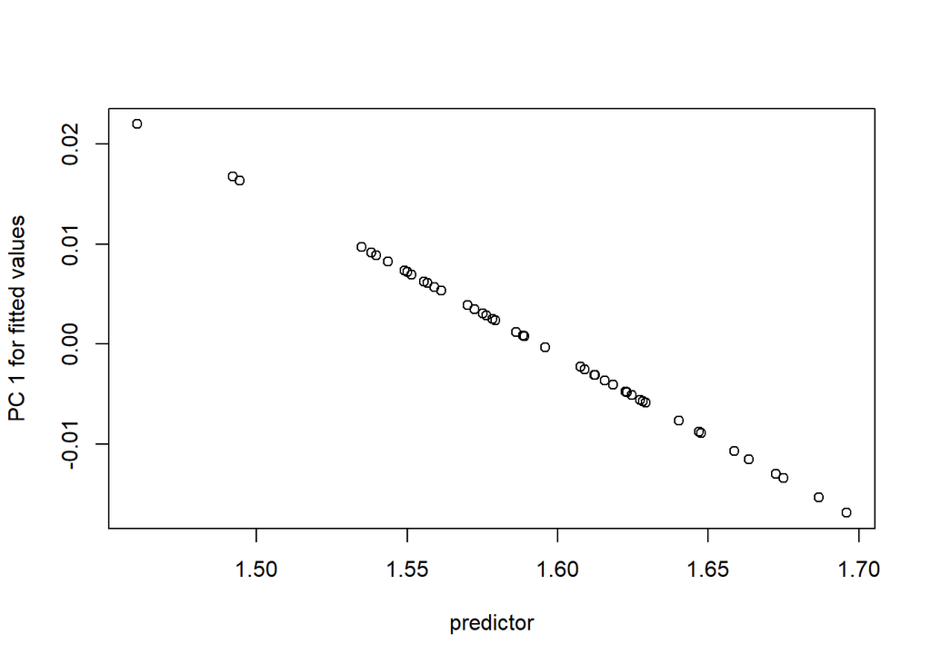

```r
#is a significant relationship between size and shape
#visiualise
#plotAllometry(fit.size,size=gdf$Csize, logsz=TRUE,method='PredLine',col=as.factor(species_list),pch=19)
#plot with legend etc
p<-plotAllometry(fit.size,size=gdf$Csize, logsz=TRUE,method='PredLine')
```

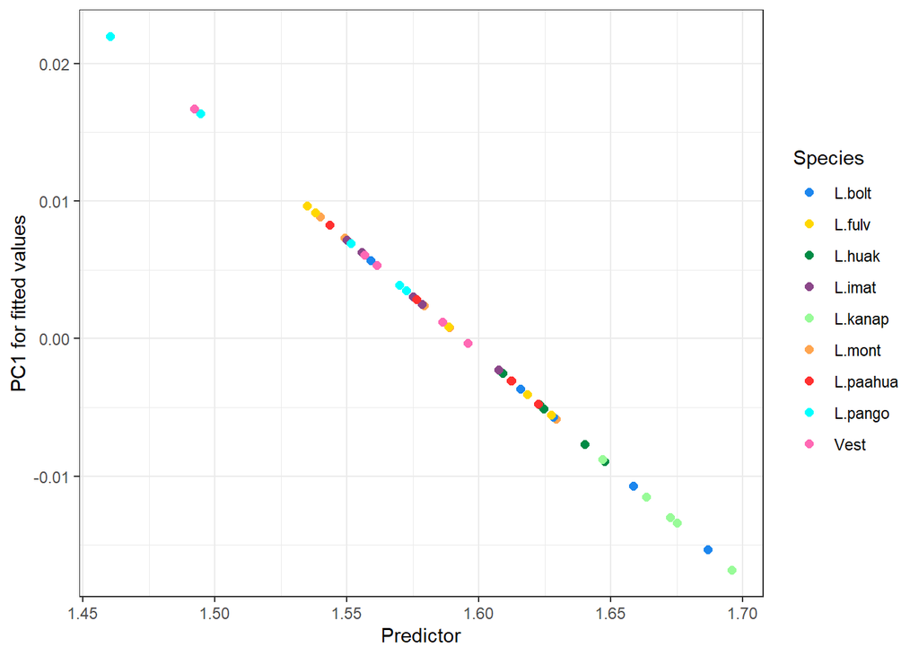

```r
p<-cbind(as.data.frame(p$plot_args$x),as.data.frame(p$plot_args$y))
names(p)[names(p) == 'p$plot_args$x'] <- 'PredLine'
names(p)[names(p) == 'p$plot_args$y'] <- 'PC1'
p<-rownames_to_column(p,var='ID')
p$bee_species<-gsub('_.*','',p$ID)

ggplot(p,aes(x=PredLine,y=PC1,colour = bee_species))+
  geom_point(size=2) +
  theme_bw()+
  scale_color_manual(values=col)+
  labs(colour='Species',x='Predictor',y='PC1 for fitted values')
```

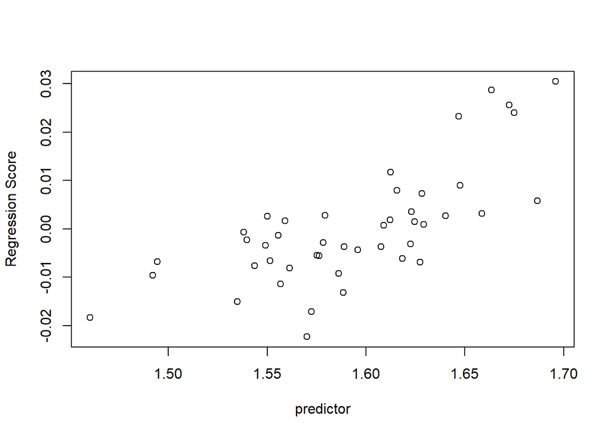

```r
#same thing here:
#plot(fit.size,type='regression',reg.type="PredLine", predictor =log(gdf$Csize))
#first principal component scores fitted values - PredLine

#regression scores-standardised regression shapes
#plotAllometry(fit.size,size=gdf$Csize, logsz=TRUE,method='RegScore',col=as.factor(species_list),pch=19)
#plot with legend etc
p<-plotAllometry(fit.size,size=gdf$Csize, logsz=TRUE,method='RegScore')
```

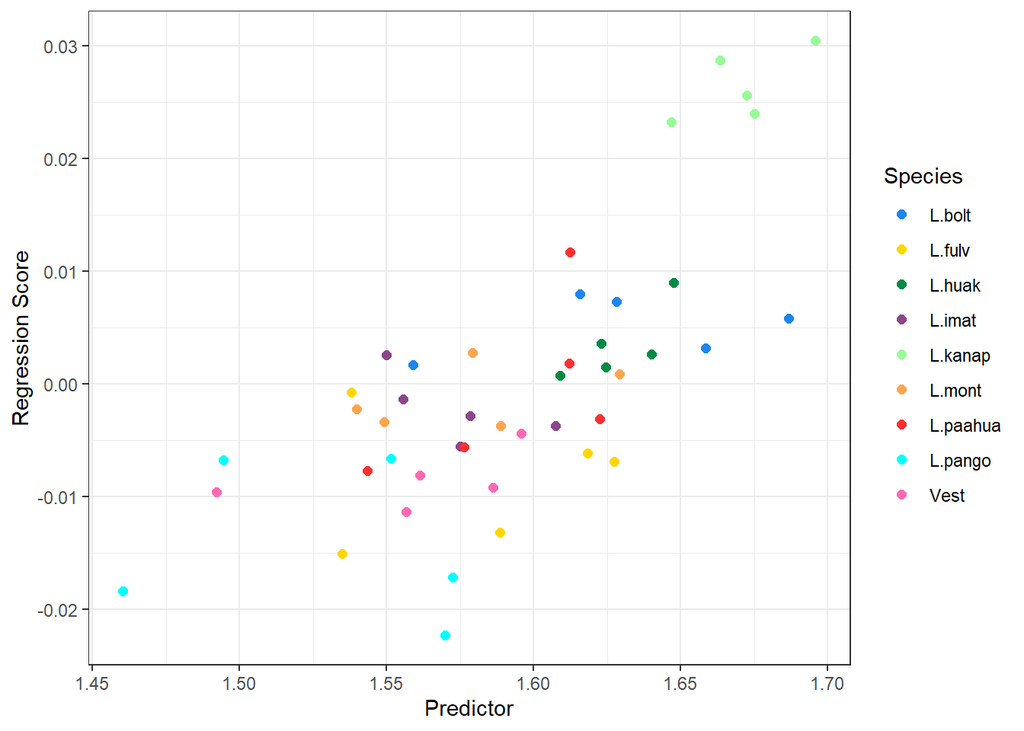

```r
p<-cbind(as.data.frame(p$plot_args$x),as.data.frame(p$plot_args$y))
names(p)[names(p) == 'p$plot_args$x'] <- 'PredLine'
names(p)[names(p) == 'V1'] <- 'RegScore'
p<-rownames_to_column(p,var='ID')
p$bee_species<-gsub('_.*','',p$ID)

ggplot(p,aes(x=PredLine,y=RegScore,colour = bee_species))+
  geom_point(size=2)+
  theme_bw()+
  scale_color_manual(values=col)+
  labs(colour='Species',x='Predictor',y='Regression Score')
```

```r
#partial least squares for relationship between shape and size
PLS<-two.b.pls(log(gdf$Csize),gdf$coords,print.progress=F)
PLS
```

```
##
## Call:
## two.b.pls(A1 = log(gdf$Csize), A2 = gdf$coords, print.progress = F)
##
##
##
## r-PLS: 0.723
##
## Effect Size (Z): 3.4359
##
## P-value: 0.001
##
## Based on 1000 random permutations
```

```r
#
```

## Relationship between size, shape and species

using Procrustes ANOVA/regression. Not convienced that I have this right and that this is the best way in regards to the posthoc pairwise tests. There is another function which I havent really explored that might be better for this.

```r
#look at the influence of shape, size and species
fit.common<-procD.lm(coords~log(Csize)+species,data=gdf)
summary(fit.common)
```

```
##
## Analysis of Variance, using Residual Randomization
## Permutation procedure: Randomization of null model residuals
## Number of permutations: 1000
## Estimation method: Ordinary Least Squares
## Sums of Squares and Cross-products: Type I
## Effect sizes (Z) based on F distributions
##
##            Df       SS        MS     Rsq      F      Z Pr(>F)
## log(Csize)  1 0.003258 0.0032580 0.05821 6.3692 4.5054  0.001 ***
## species     8 0.034810 0.0043513 0.62193 8.5066 8.9917  0.001 ***
## Residuals  35 0.017903 0.0005115 0.31986
## Total      44 0.055972
## ---
## Signif. codes:  0 '***' 0.001 '**' 0.01 '*' 0.05 '.' 0.1 ' ' 1
##
## Call: procD.lm(f1 = coords ~ log(Csize) + species, data = gdf)
```

```r
PW<-pairwise(fit.common,groups=species_list)
summary(PW)
```

```
##
## Pairwise comparisons
##
## Groups: L.bolt L.fulv L.huak L.imat L.kanap L.mont L.paahua L.pango Vest
##
## RRPP: 1000 permutations
##
## LS means:
## Vectors hidden (use show.vectors = TRUE to view)
##
## Pairwise distances between means, plus statistics
##                           d  UCL (95%)         Z Pr > d
## L.bolt:L.fulv    0.04531127 0.03255641 2.8470078  0.003
## L.bolt:L.huak    0.02670564 0.03086821 1.0403752  0.147
## L.bolt:L.imat    0.02785633 0.03301796 0.9543599  0.168
## L.bolt:L.kanap   0.03366972 0.03284632 1.8367482  0.034
## L.bolt:L.mont    0.02832851 0.03212630 1.0690440  0.149
## L.bolt:L.paahua  0.04884810 0.03186081 3.4512137  0.001
## L.bolt:L.pango   0.03506123 0.03826744 1.2638915  0.106
## L.bolt:Vest      0.03484321 0.03504632 1.6530026  0.052
## L.fulv:L.huak    0.05157728 0.03296199 3.5476462  0.001
## L.fulv:L.imat    0.05087672 0.03121529 3.8369946  0.001
## L.fulv:L.kanap   0.05720813 0.03734155 3.3746598  0.001
## L.fulv:L.mont    0.04384942 0.03070015 3.1675424  0.001
## L.fulv:L.paahua  0.03603393 0.03096449 2.3106397  0.007
## L.fulv:L.pango   0.05230147 0.03304278 3.7633482  0.001
## L.fulv:Vest      0.04968463 0.03105219 3.3356927  0.002
## L.huak:L.imat    0.02649072 0.03365635 0.6890652  0.243
## L.huak:L.kanap   0.03792746 0.03179834 2.4111919  0.010
## L.huak:L.mont    0.02916735 0.03276353 1.1650657  0.124
## L.huak:L.paahua  0.04969710 0.03134611 3.4968832  0.001
## L.huak:L.pango   0.04803959 0.03803635 2.5886227  0.006
## L.huak:Vest      0.03821452 0.03447863 2.0809932  0.019
## L.imat:L.kanap   0.04352542 0.03776942 2.2840803  0.014
## L.imat:L.mont    0.03407002 0.03094335 2.1455039  0.016
## L.imat:L.paahua  0.05949540 0.03085848 4.5001574  0.001
## L.imat:L.pango   0.04445043 0.03324024 2.8330807  0.001
## L.imat:Vest      0.04176174 0.03075612 2.8856256  0.003
## L.kanap:L.mont   0.03525106 0.03721674 1.4568329  0.071
## L.kanap:L.paahua 0.05500130 0.03526889 3.5147953  0.001
## L.kanap:L.pango  0.05432726 0.04334533 2.4105800  0.009
## L.kanap:Vest     0.04942458 0.03880895 2.6690622  0.005
## L.mont:L.paahua  0.04619682 0.03075785 3.2929206  0.001
## L.mont:L.pango   0.04687614 0.03273294 3.2271350  0.001
## L.mont:Vest      0.04246056 0.03185981 2.7723137  0.003
## L.paahua:L.pango 0.06573242 0.03402027 4.5072019  0.001
## L.paahua:Vest    0.06009469 0.03117701 4.4772059  0.001
## L.pango:Vest     0.02655723 0.03179480 0.9209957  0.176
```

```r
#relationship between size and species
fit1<-procD.lm(log(gdf$Csize)~species_list)
summary(fit1)
```

```
##
## Analysis of Variance, using Residual Randomization
## Permutation procedure: Randomization of null model residuals
## Number of permutations: 1000
## Estimation method: Ordinary Least Squares
## Sums of Squares and Cross-products: Type I
## Effect sizes (Z) based on F distributions
##
##              Df       SS        MS    Rsq     F      Z Pr(>F)
## species_list  8 0.073203 0.0091504 0.6089 7.006 4.4796  0.001 ***
## Residuals    36 0.047019 0.0013061 0.3911
## Total        44 0.120222
## ---
## Signif. codes:  0 '***' 0.001 '**' 0.01 '*' 0.05 '.' 0.1 ' ' 1
##
## Call: procD.lm(f1 = log(gdf$Csize) ~ species_list)
```

```r
PW<-pairwise(fit1,groups=species_list)
summary(PW)
```

```
##
## Pairwise comparisons
##
## Groups: L.bolt L.fulv L.huak L.imat L.kanap L.mont L.paahua L.pango Vest
##
## RRPP: 1000 permutations
##
## LS means:
## Vectors hidden (use show.vectors = TRUE to view)
##
## Pairwise distances between means, plus statistics
##                             d  UCL (95%)           Z Pr > d
## L.bolt:L.fulv    0.0482007936 0.06425394  1.09603301  0.150
## L.bolt:L.huak    0.0007612524 0.06290692 -1.96516603  0.975
## L.bolt:L.imat    0.0563224097 0.06254512  1.37798957  0.078
## L.bolt:L.kanap   0.0410823034 0.06297393  0.85972515  0.198
## L.bolt:L.mont    0.0524520410 0.06668841  1.15774461  0.137
## L.bolt:L.paahua  0.0362931362 0.06385172  0.56829905  0.311
## L.bolt:L.pango   0.0999311083 0.06698147  2.42335360  0.001
## L.bolt:Vest      0.0712326672 0.06501426  1.72522778  0.032
## L.fulv:L.huak    0.0474395412 0.06468450  1.04453487  0.164
## L.fulv:L.imat    0.0081216161 0.06410193 -0.98786785  0.816
## L.fulv:L.kanap   0.0892830970 0.06421477  2.27440205  0.003
## L.fulv:L.mont    0.0042512474 0.06738131 -1.37329498  0.898
## L.fulv:L.paahua  0.0119076574 0.06605926 -0.65305517  0.733
## L.fulv:L.pango   0.0517303147 0.06427209  1.19560245  0.120
## L.fulv:Vest      0.0230318736 0.06566602  0.07834945  0.483
## L.huak:L.imat    0.0555611573 0.06536427  1.31736676  0.104
## L.huak:L.kanap   0.0418435558 0.06602727  0.86028567  0.196
## L.huak:L.mont    0.0516907886 0.06420454  1.18696564  0.125
## L.huak:L.paahua  0.0355318838 0.06486461  0.61004192  0.288
## L.huak:L.pango   0.0991698558 0.06628962  2.38547503  0.004
## L.huak:Vest      0.0704714148 0.06402764  1.81655029  0.025
## L.imat:L.kanap   0.0974047131 0.06355545  2.42802002  0.001
## L.imat:L.mont    0.0038703687 0.06688260 -1.43670378  0.912
## L.imat:L.paahua  0.0200292735 0.06365201 -0.09157265  0.546
## L.imat:L.pango   0.0436086986 0.06349942  0.91334754  0.192
## L.imat:Vest      0.0149102575 0.06395512 -0.43540733  0.675
## L.kanap:L.mont   0.0935343444 0.06701762  2.28366537  0.003
## L.kanap:L.paahua 0.0773754396 0.06253126  1.91932472  0.024
## L.kanap:L.pango  0.1410134116 0.06465138  3.24036191  0.001
## L.kanap:Vest     0.1123149706 0.06307914  2.72703509  0.001
## L.mont:L.paahua  0.0161589048 0.06593831 -0.39687865  0.651
## L.mont:L.pango   0.0474790673 0.06345923  0.99463123  0.167
## L.mont:Vest      0.0187806262 0.06679711 -0.18454917  0.574
## L.paahua:L.pango 0.0636379720 0.06589807  1.52830722  0.058
## L.paahua:Vest    0.0349395310 0.06771106  0.58770133  0.298
## L.pango:Vest     0.0286984410 0.06829484  0.27536450  0.419
```

```r
#relationship between shape and species
fit2<-procD.lm(gdf$coords~species_list)
summary(fit2)
```

```
##
## Analysis of Variance, using Residual Randomization
## Permutation procedure: Randomization of null model residuals
## Number of permutations: 1000
## Estimation method: Ordinary Least Squares
## Sums of Squares and Cross-products: Type I
## Effect sizes (Z) based on F distributions
##
##              Df       SS        MS     Rsq      F      Z Pr(>F)
## species_list  8 0.037091 0.0046364 0.66267 8.8402 9.6712  0.001 ***
## Residuals    36 0.018881 0.0005245 0.33733
## Total        44 0.055972
## ---
## Signif. codes:  0 '***' 0.001 '**' 0.01 '*' 0.05 '.' 0.1 ' ' 1
##
## Call: procD.lm(f1 = gdf$coords ~ species_list)
```

```r
PW<-pairwise(fit2,groups=species_list)
summary(PW)
```

```
##
## Pairwise comparisons
##
## Groups: L.bolt L.fulv L.huak L.imat L.kanap L.mont L.paahua L.pango Vest
##
## RRPP: 1000 permutations
##
## LS means:
## Vectors hidden (use show.vectors = TRUE to view)
##
## Pairwise distances between means, plus statistics
##                           d  UCL (95%)         Z Pr > d
## L.bolt:L.fulv    0.04497831 0.03149097 3.0496985  0.002
## L.bolt:L.huak    0.02674946 0.03132019 0.9578008  0.162
## L.bolt:L.imat    0.02997763 0.03079074 1.4829509  0.065
## L.bolt:L.kanap   0.03266425 0.03192129 1.8415494  0.040
## L.bolt:L.mont    0.03192399 0.03136758 1.7559086  0.043
## L.bolt:L.paahua  0.05056433 0.03108049 3.8057251  0.001
## L.bolt:L.pango   0.02873741 0.03201005 1.2272403  0.113
## L.bolt:Vest      0.03146849 0.03113100 1.6405280  0.047
## L.fulv:L.huak    0.04984614 0.03127656 3.7480703  0.001
## L.fulv:L.imat    0.05109987 0.03156929 3.8554731  0.001
## L.fulv:L.kanap   0.05542683 0.03191697 4.0567221  0.001
## L.fulv:L.mont    0.04407927 0.03118755 3.2161363  0.001
## L.fulv:L.paahua  0.03514312 0.03149770 2.1730257  0.014
## L.fulv:L.pango   0.05058515 0.03188000 3.9325715  0.001
## L.fulv:Vest      0.04909756 0.03127932 3.4571872  0.002
## L.huak:L.imat    0.02553036 0.03167343 0.7382205  0.227
## L.huak:L.kanap   0.03872116 0.03155221 2.5528553  0.004
## L.huak:L.mont    0.03008577 0.03156565 1.4699287  0.081
## L.huak:L.paahua  0.05027417 0.03103102 3.9667524  0.001
## L.huak:L.pango   0.04002799 0.03178556 2.5522626  0.006
## L.huak:Vest      0.03197013 0.03107852 1.7519691  0.041
## L.imat:L.kanap   0.04414176 0.03153094 3.2026963  0.001
## L.imat:L.mont    0.03395897 0.03118003 2.0326416  0.022
## L.imat:L.paahua  0.05906922 0.03119955 4.5236418  0.001
## L.imat:L.pango   0.04128910 0.03216178 2.7093914  0.001
## L.imat:Vest      0.04080102 0.03103979 2.7800394  0.007
## L.kanap:L.mont   0.03843303 0.03098251 2.5788331  0.006
## L.kanap:L.paahua 0.05712501 0.03136655 4.2677540  0.001
## L.kanap:L.pango  0.04640262 0.03141190 3.4273990  0.002
## L.kanap:Vest     0.04367606 0.03120349 3.0201037  0.001
## L.mont:L.paahua  0.04609687 0.03121275 3.3233769  0.001
## L.mont:L.pango   0.04253925 0.03138413 3.0520432  0.002
## L.mont:Vest      0.04082071 0.03207681 2.6435880  0.004
## L.paahua:L.pango 0.06135685 0.03116473 4.8452761  0.001
## L.paahua:Vest    0.05776985 0.03103795 4.3503299  0.001
## L.pango:Vest     0.02606878 0.03190266 0.8201082  0.212
```

```r
#does shape differ between species, while accounting for shape co varying with size
#not convinced I have this model right, I think its an over simplification
fit3<-procD.lm(gdf$coords ~log(gdf$Csize)*species_list)
summary(fit3)
```

```
##
## Analysis of Variance, using Residual Randomization
## Permutation procedure: Randomization of null model residuals
## Number of permutations: 1000
## Estimation method: Ordinary Least Squares
## Sums of Squares and Cross-products: Type I
## Effect sizes (Z) based on F distributions
##
##                             Df       SS        MS     Rsq      F       Z Pr(>F)
## log(gdf$Csize)               1 0.003258 0.0032580 0.05821 6.2070  4.4317  0.001
## species_list                 8 0.034810 0.0043513 0.62193 8.2900  8.7626  0.001
## log(gdf$Csize):species_list  8 0.003731 0.0004664 0.06666 0.8886 -0.5807  0.720
## Residuals                   27 0.014172 0.0005249 0.25320
## Total                       44 0.055972
##
## log(gdf$Csize)              ***
## species_list                ***
## log(gdf$Csize):species_list
## Residuals
## Total
## ---
## Signif. codes:  0 '***' 0.001 '**' 0.01 '*' 0.05 '.' 0.1 ' ' 1
##
## Call: procD.lm(f1 = gdf$coords ~ log(gdf$Csize) * species_list)
```

```r
#posthoc test between groups
PW<-pairwise(fit3,groups=species_list)
summary(PW)
```

```
##
## Pairwise comparisons
##
## Groups: L.bolt L.fulv L.huak L.imat L.kanap L.mont L.paahua L.pango Vest
##
## RRPP: 1000 permutations
##
## LS means:
## Vectors hidden (use show.vectors = TRUE to view)
##
## Pairwise distances between means, plus statistics
##                           d  UCL (95%)           Z Pr > d
## L.bolt:L.fulv    0.04624221 0.05211244 -0.52095744  0.689
## L.bolt:L.huak    0.03584280 0.05082865 -0.25788113  0.612
## L.bolt:L.imat    0.02826327 0.03843380 -1.26877831  0.905
## L.bolt:L.kanap   0.03861955 0.07339426 -2.23612000  0.984
## L.bolt:L.mont    0.03028749 0.03719684 -0.70375665  0.778
## L.bolt:L.paahua  0.05227576 0.05759487  0.39440620  0.349
## L.bolt:L.pango   0.04153366 0.04817055  0.33458662  0.363
## L.bolt:Vest      0.03831686 0.04614163 -0.06438987  0.516
## L.fulv:L.huak    0.05961665 0.06510155  0.42594728  0.355
## L.fulv:L.imat    0.05100547 0.05788523 -0.80771132  0.784
## L.fulv:L.kanap   0.06083901 0.08600616 -1.47190066  0.927
## L.fulv:L.mont    0.04377122 0.04957320 -0.93819504  0.822
## L.fulv:L.paahua  0.03486333 0.04329436 -1.03555363  0.846
## L.fulv:L.pango   0.05855705 0.06282554  0.72051030  0.256
## L.fulv:Vest      0.05141900 0.05833478 -0.15455522  0.567
## L.huak:L.imat    0.03519327 0.04981878 -0.39898231  0.665
## L.huak:L.kanap   0.04991795 0.08115069 -1.18776130  0.883
## L.huak:L.mont    0.03919459 0.04994074  0.05645953  0.482
## L.huak:L.paahua  0.05891875 0.06543547  0.50551557  0.312
## L.huak:L.pango   0.04307980 0.06972167 -1.82391285  0.964
## L.huak:Vest      0.03904124 0.05859145 -1.12858982  0.869
## L.imat:L.kanap   0.04070395 0.08144541 -2.42223205  0.990
## L.imat:L.mont    0.03486475 0.04280756 -1.02499074  0.853
## L.imat:L.paahua  0.05980426 0.06805918 -0.40623642  0.653
## L.imat:L.pango   0.04646633 0.05689875 -0.45421722  0.669
## L.imat:Vest      0.04402418 0.05315346 -0.33329606  0.629
## L.kanap:L.mont   0.04053310 0.07256829 -2.11269967  0.983
## L.kanap:L.paahua 0.06088228 0.08702184 -1.08807359  0.859
## L.kanap:L.pango  0.06416953 0.08949927 -0.59152406  0.724
## L.kanap:Vest     0.05759337 0.08472941 -0.79106334  0.776
## L.mont:L.paahua  0.04702288 0.05342648 -0.29446835  0.602
## L.mont:L.pango   0.05276382 0.05763452  0.50883688  0.311
## L.mont:Vest      0.04647244 0.05251808  0.26010462  0.401
## L.paahua:L.pango 0.07386060 0.07677582  1.14955446  0.137
## L.paahua:Vest    0.06138745 0.06881013 -0.08226973  0.534
## L.pango:Vest     0.02860888 0.04168822 -0.88379931  0.811
```

```r
#
```

## Hind wing analysis

Same but on hind wing

```r
#bring in TPS file
bees<-readland.tps('C:/Users/hrlexd/Dropbox/PlantAndFood (1)/NativeBees/Bee_pictures/Hindwings_merged_cleaned_19_05_2025.TPS',specID = 'imageID')
```

```
##
## No curves detected; all points appear to be fixed landmarks.
```

```r
#generate a file of species names for each sample etc for plotting
Sample_names<-labels(bees)[[3]]
Sample_names
```

```
##  [1] "L.bolt_4"   "L.mont_1"   "L.mont_2"   "L.mont_3"   "L.mont_4"
##  [6] "L.mont_5"   "L.bolt_1"   "L.bolt_2"   "L.bolt_3"   "L.bolt_5"
## [11] "L.fulv_1"   "L.fulv_2"   "L.fulv_3"   "L.fulv_4"   "L.fulv_5"
## [16] "L.huak_1"   "L.huak_2"   "L.huak_3"   "L.huak_4"   "L.huak_5"
## [21] "L.imat_1"   "L.imat_2"   "L.imat_3"   "L.imat_4"   "L.imat_5"
## [26] "L.kanap_1"  "L.kanap_2"  "L.kanap_3"  "L.kanap_4"  "L.kanap_5"
## [31] "L.paahua_1" "L.paahua_2" "L.paahua_3" "L.paahua_4" "L.paahua_5"
## [36] "L.pango_1"  "L.pango_2"  "L.pango_3"  "L.pango_4"  "L.pango_5"
## [41] "Vest_1"     "Vest_2"     "Vest_3"     "Vest_4"     "Vest_5"
```

```r
#Sample_names<-gsub('.*\\\\','',Sample_names)
#Sample_names<-sub("([A-Za-z].[A-Za-z]+_[0-9]+).*", "\\1", Sample_names)
species_list<-gsub('_.*','',Sample_names)
#species_list<-gsub('L.Kanap','L.kanap',species_list)
unique(species_list)
```

```
## [1] "L.bolt"   "L.mont"   "L.fulv"   "L.huak"   "L.imat"   "L.kanap"  "L.paahua"
## [8] "L.pango"  "Vest"
```

```r
#do a generalixed procrustes analysis on TPS
beesgpa<-gpagen(bees)
```

```
##
## Performing GPA
##   |                                                                              |                                                                      |   0%  |                                                                              |==================                                       …
##
## Making projections... Finished!
```

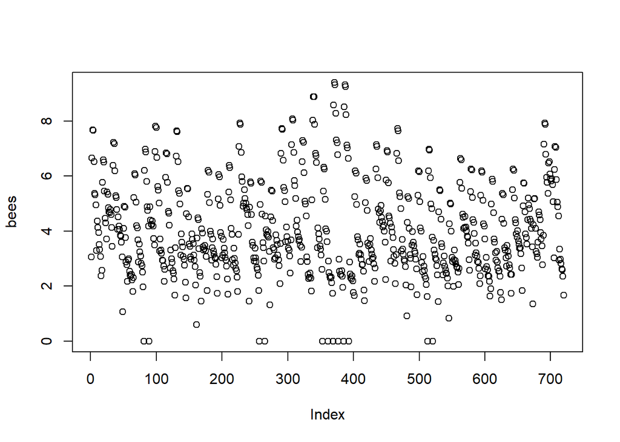

```r
#checking procrustes fit
#plot before procrustes
plot(bees)
```

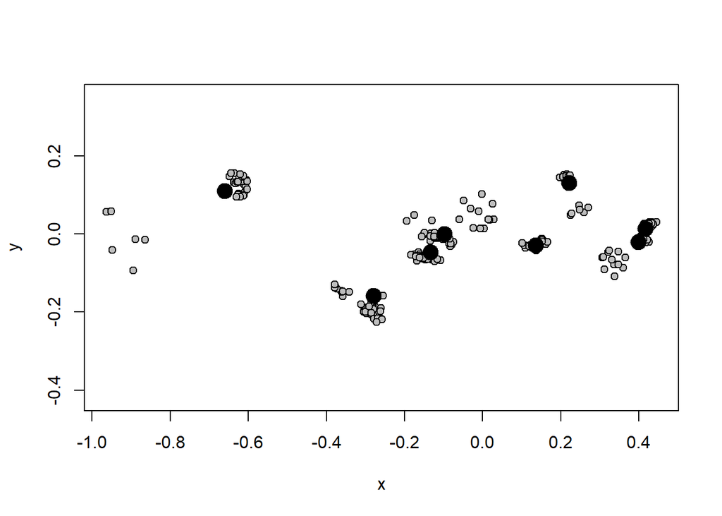

```r
#plot after procrustes
plot(beesgpa)
```

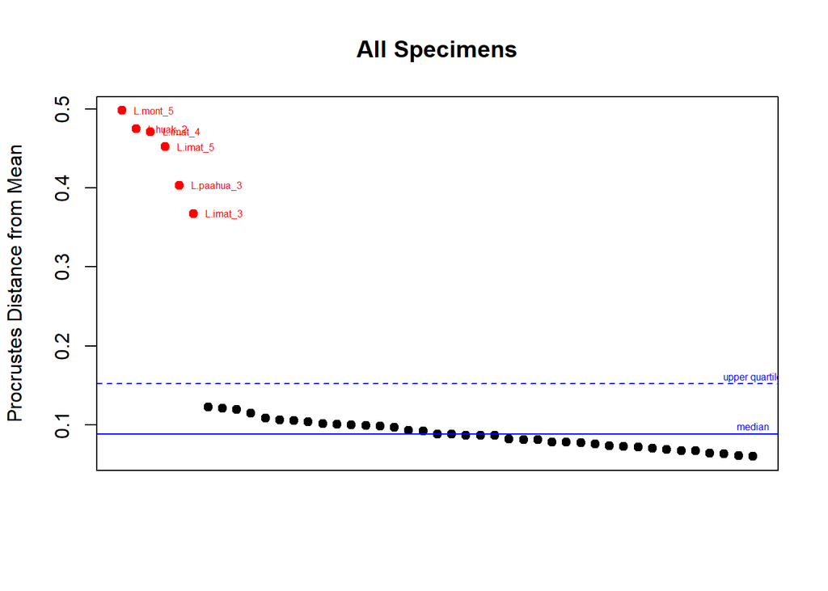

```
##   L.mont_5   L.huak_2   L.imat_4   L.imat_5 L.paahua_3   L.imat_3 L.paahua_1
##          6         17         24         25         33         23         31
## L.paahua_4 L.paahua_2   L.fulv_5     Vest_3     Vest_5  L.pango_4   L.fulv_1
##         34         32         15         43         45         39         11
##   L.fulv_4   L.imat_2   L.fulv_2  L.pango_5   L.imat_1   L.bolt_5     Vest_2
##         14         22         12         40         21         10         42
## L.paahua_5  L.kanap_1     Vest_4  L.pango_1   L.huak_4  L.kanap_2  L.pango_2
##         35         26         44         36         19         27         37
##   L.mont_1   L.mont_3   L.fulv_3   L.bolt_3   L.huak_3  L.kanap_3   L.mont_4
##          2          4         13          9         18         28          5
##   L.huak_5   L.mont_2  L.kanap_4  L.kanap_5  L.pango_3     Vest_1   L.bolt_4
##         20          3         29         30         38         41          1
##   L.bolt_1   L.huak_1   L.bolt_2
##          7         16          8
```

```r
#plot outliers
plotOutliers(beesgpa$coords)
```

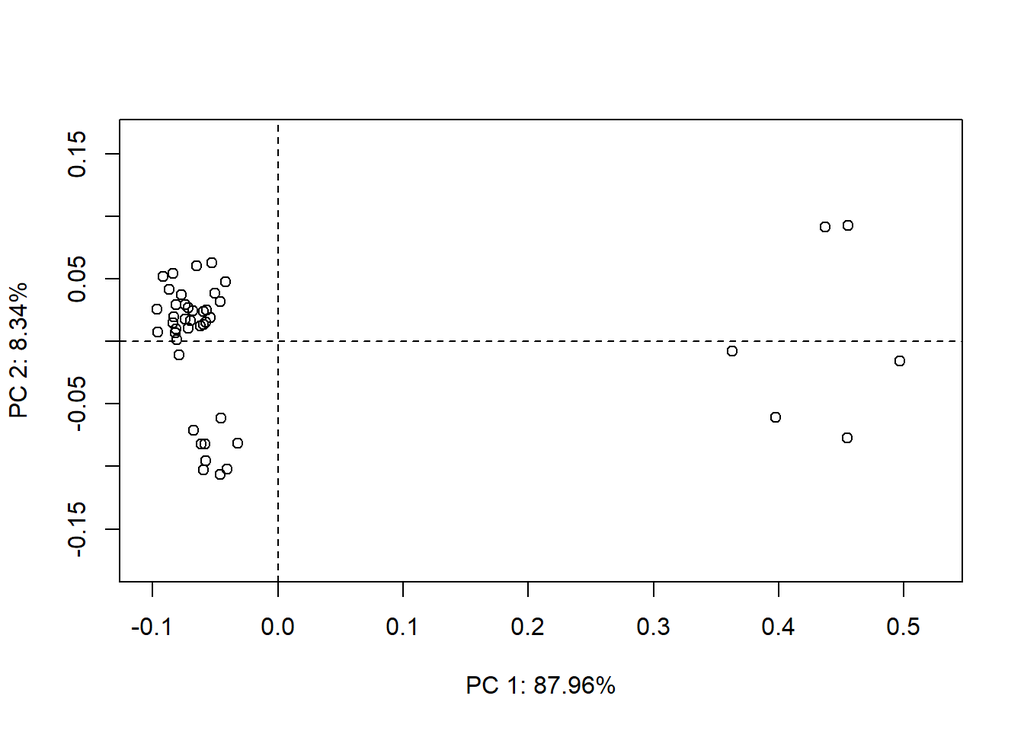

```r
#the first point looks very dodgy
PCA<-gm.prcomp(beesgpa$coords)
plot(PCA)
```

```r
#thats all just those varable ones on the first point again so doesnt work on either fore or hind wing for point 1
```

## Dropping first point

That first point just isnt stable so think we can drop it form now on.

```r
bees_removefirst <- bees[-1,,]
beesgpa<-gpagen(bees_removefirst)
```

```
##
## Performing GPA
##   |                                                                              |                                                                      |   0%  |                                                                              |==================                                       …
##
## Making projections... Finished!
```

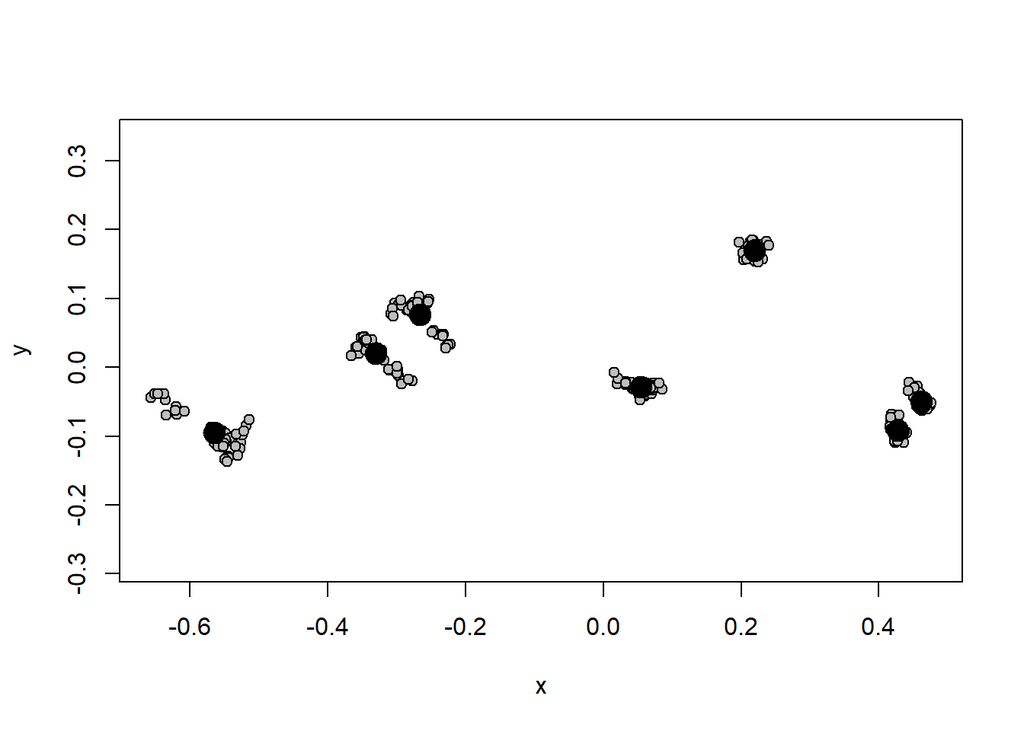

```r
#looks more stable
plot(beesgpa)
```

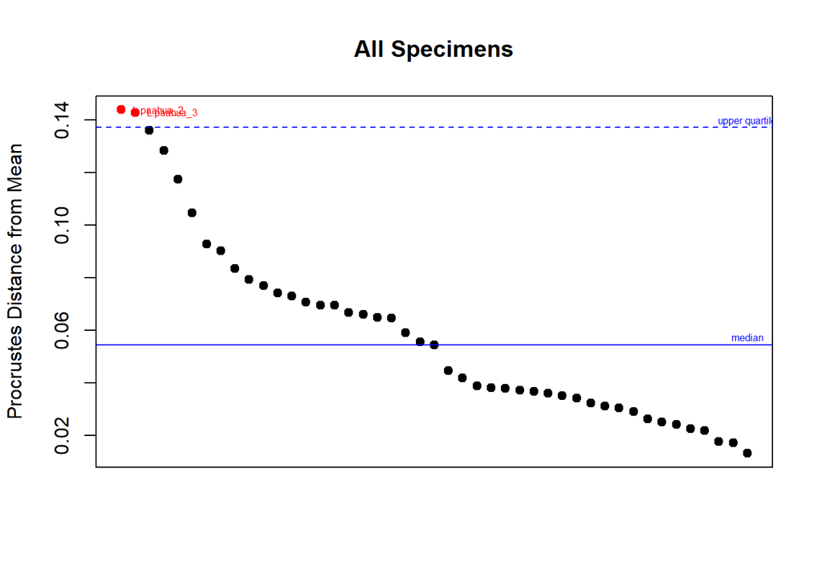

```
## L.paahua_2 L.paahua_3 L.paahua_4 L.paahua_1   L.fulv_5 L.paahua_5   L.fulv_1
##         32         33         34         31         15         35         11
##   L.fulv_4   L.fulv_2  L.kanap_3     Vest_5   L.fulv_3     Vest_3   L.imat_3
##         14         12         28         45         13         43         23
##   L.imat_5     Vest_2  L.kanap_4     Vest_4   L.imat_2   L.imat_1  L.pango_5
##         25         42         29         44         22         21         40
##  L.pango_4   L.imat_4  L.kanap_5     Vest_1  L.pango_2  L.pango_1  L.kanap_2
##         39         24         30         41         37         36         27
##   L.huak_2   L.bolt_4  L.kanap_1  L.pango_3   L.huak_4   L.bolt_3   L.huak_5
##         17          1         26         38         19          9         20
##   L.bolt_2   L.huak_3   L.bolt_1   L.huak_1   L.mont_3   L.mont_4   L.mont_2
##          8         18          7         16          4          5          3
##   L.mont_5   L.bolt_5   L.mont_1
##          6         10          2
```

```r
#plot outliers
plotOutliers(beesgpa$coords)
```

```r
#run PCA analysis
PCA<-gm.prcomp(beesgpa$coords)
#plot(PCA)
#plot with legend
PCaxis<-as.data.frame(PCA$x[,1:2])
PCaxis<-rownames_to_column(PCaxis,var='ID')
PCaxis$bee_species<-gsub('_.*','',PCaxis$ID)

#set colours
col<-as.character(c("dodgerblue2","tan1","gold1","springgreen4","orchid4","palegreen","firebrick1","cyan1","hotpink"))
names(col)<-as.character(unique(PCaxis$bee_species))
col
```

```
##         L.bolt         L.mont         L.fulv         L.huak         L.imat
##  "dodgerblue2"         "tan1"        "gold1" "springgreen4"      "orchid4"
##        L.kanap       L.paahua        L.pango           Vest
##    "palegreen"   "firebrick1"        "cyan1"      "hotpink"
```

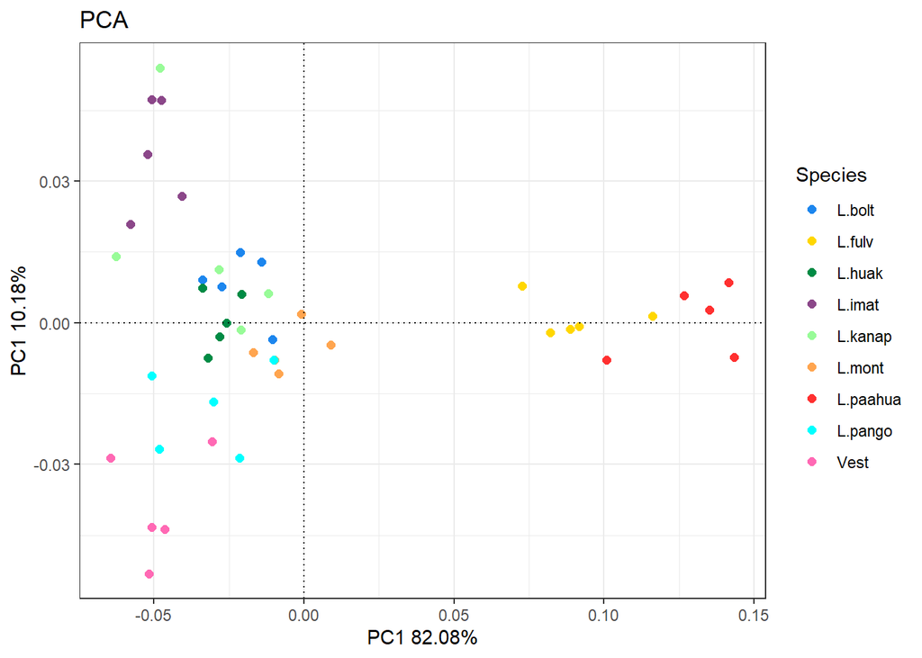

```r
#extract PC % from sdev
PC1_per<-round(as.data.frame(PCA$sdev^2/sum(PCA$sdev^2))[1,1]*100,digits=2)
PC2_per<-round(as.data.frame(PCA$sdev^2/sum(PCA$sdev^2))[2,1]*100,digits=2)
#plot
ggplot(PCaxis,aes(x=Comp1,y=Comp2,colour = bee_species))+
  geom_point(size=2)+
  theme_bw()+
  scale_color_manual(values=col)+
  labs(colour='Species',x=paste0('PC1 ',PC1_per,'%'),y=paste0('PC1 ',PC2_per,'%'),title="PCA")+
  geom_hline(yintercept=0, linetype='dotted', col = 'black')+
  geom_vline(xintercept=0, linetype='dotted', col = 'black')
```

```r
#
```

## Within Leioproctus Leioproctus

Just wanted to have a quick look just within leioproctus leiopructus (plus monitcola) as I notice on the PCA most of the variaiton is just between two neso species and Leio species (plus monitcola)

```r
#just looking with in leioproctus
#I think fulvesencs and paahua are only neso but could be wrong
#redo procrustes just with Leioproctus leioproctus species
Sample_names
```

```
##  [1] "L.bolt_4"   "L.mont_1"   "L.mont_2"   "L.mont_3"   "L.mont_4"
##  [6] "L.mont_5"   "L.bolt_1"   "L.bolt_2"   "L.bolt_3"   "L.bolt_5"
## [11] "L.fulv_1"   "L.fulv_2"   "L.fulv_3"   "L.fulv_4"   "L.fulv_5"
## [16] "L.huak_1"   "L.huak_2"   "L.huak_3"   "L.huak_4"   "L.huak_5"
## [21] "L.imat_1"   "L.imat_2"   "L.imat_3"   "L.imat_4"   "L.imat_5"
## [26] "L.kanap_1"  "L.kanap_2"  "L.kanap_3"  "L.kanap_4"  "L.kanap_5"
## [31] "L.paahua_1" "L.paahua_2" "L.paahua_3" "L.paahua_4" "L.paahua_5"
## [36] "L.pango_1"  "L.pango_2"  "L.pango_3"  "L.pango_4"  "L.pango_5"
## [41] "Vest_1"     "Vest_2"     "Vest_3"     "Vest_4"     "Vest_5"
```

```r
bees_leioproctus <- bees[,,-c(11:15,31:35)]
bees_leioproctus <- bees_leioproctus[-1,,]
beesgpa_leio<-gpagen(bees_leioproctus)
```

```
##
## Performing GPA
##   |                                                                              |                                                                      |   0%  |                                                                              |==================                                       …
##
## Making projections... Finished!
```

```r
Sample_names_leio<-labels(bees_leioproctus)[[3]]
Sample_names_leio<-gsub('.*\\\\','',Sample_names_leio)
species_list_leio<-gsub('_.*','',Sample_names_leio)
species_list_leio<-gsub('L.Kanap','L.kanap',species_list_leio)

unique(species_list_leio)
```

```
## [1] "L.bolt"  "L.mont"  "L.huak"  "L.imat"  "L.kanap" "L.pango" "Vest"
```

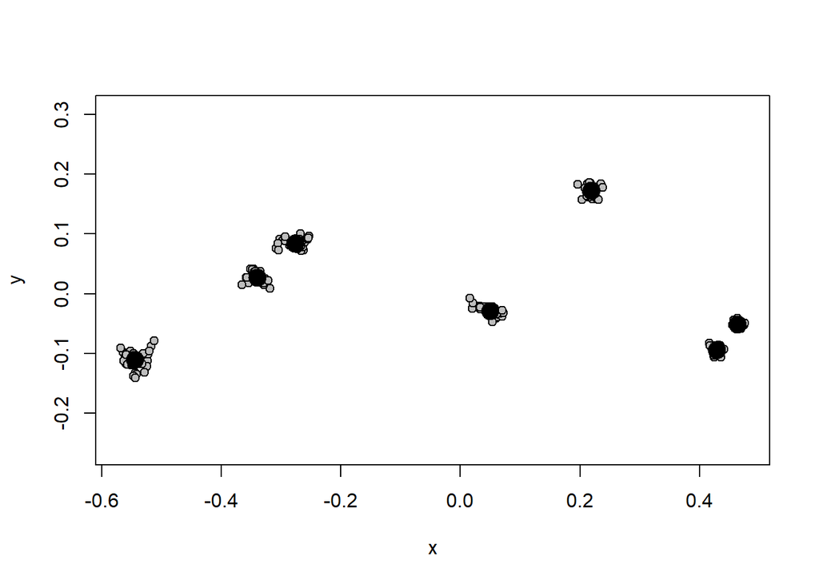

```r
plot(beesgpa_leio)
```

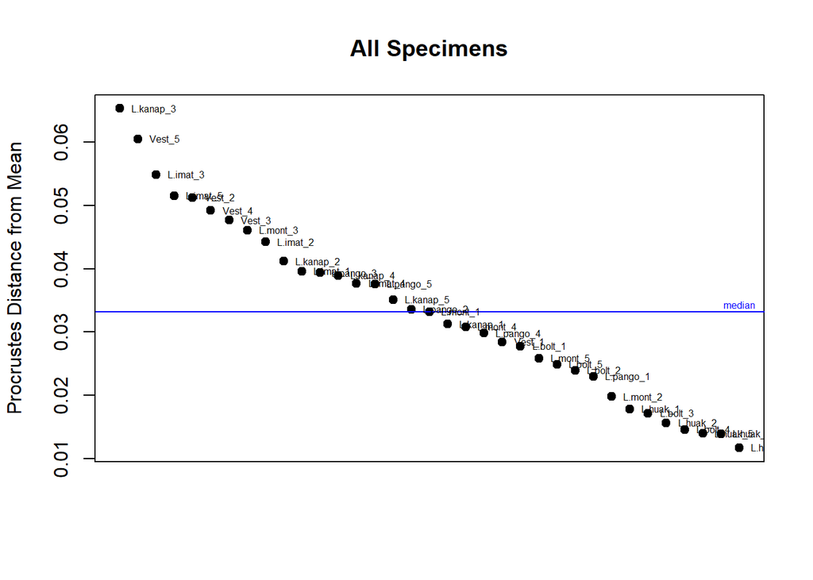

```
## L.kanap_3    Vest_5  L.imat_3  L.imat_5    Vest_2    Vest_4    Vest_3  L.mont_3
##        23        35        18        20        32        34        33         4
##  L.imat_2 L.kanap_2  L.imat_1 L.pango_3 L.kanap_4  L.imat_4 L.pango_5 L.kanap_5
##        17        22        16        28        24        19        30        25
## L.pango_2  L.mont_1 L.kanap_1  L.mont_4 L.pango_4    Vest_1  L.bolt_1  L.mont_5
##        27         2        21         5        29        31         7         6
##  L.bolt_5  L.bolt_2 L.pango_1  L.mont_2  L.huak_1  L.bolt_3  L.huak_2  L.bolt_4
##        10         8        26         3        11         9        12         1
##  L.huak_5  L.huak_3  L.huak_4
##        15        13        14
```

```r
#plot outliers
plotOutliers(beesgpa_leio$coords)
```

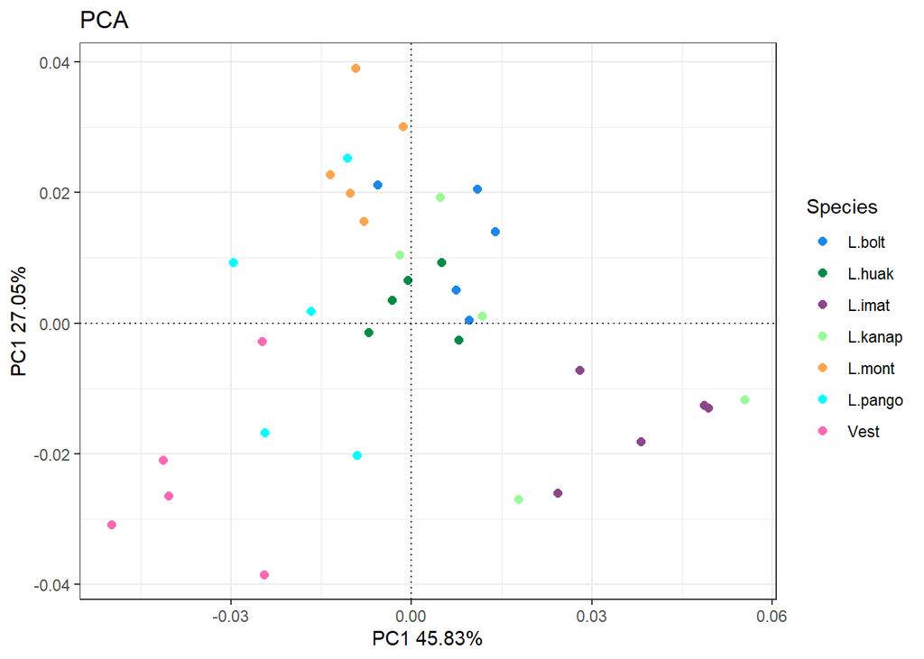

```r
#run PCA analysis
PCA<-gm.prcomp(beesgpa_leio$coords)
#summary(PCA)
#plot(PCA)
#plot with legend
PCaxis<-as.data.frame(PCA$x[,1:2])
PCaxis<-rownames_to_column(PCaxis,var='ID')
PCaxis$bee_species<-gsub('_.*','',PCaxis$ID)

PC1_per<-round(as.data.frame(PCA$sdev^2/sum(PCA$sdev^2))[1,1]*100,digits=2)
PC2_per<-round(as.data.frame(PCA$sdev^2/sum(PCA$sdev^2))[2,1]*100,digits=2)

ggplot(PCaxis,aes(x=Comp1,y=Comp2,colour = bee_species))+
  geom_point(size=2)+
  theme_bw()+
  scale_color_manual(values=col)+
  labs(colour='Species',x=paste0('PC1 ',PC1_per,'%'),y=paste0('PC1 ',PC2_per,'%'),title="PCA")+
  geom_hline(yintercept=0, linetype='dotted', col = 'black')+
  geom_vline(xintercept=0, linetype='dotted', col = 'black')
```

```r
#
```

## Shape variation

Just plotting out the shape shift of each species

```r
#shape change species compared to average
ref<-mshape(beesgpa$coords)
species_list
```

```
##  [1] "L.bolt"   "L.mont"   "L.mont"   "L.mont"   "L.mont"   "L.mont"
##  [7] "L.bolt"   "L.bolt"   "L.bolt"   "L.bolt"   "L.fulv"   "L.fulv"
## [13] "L.fulv"   "L.fulv"   "L.fulv"   "L.huak"   "L.huak"   "L.huak"
## [19] "L.huak"   "L.huak"   "L.imat"   "L.imat"   "L.imat"   "L.imat"
## [25] "L.imat"   "L.kanap"  "L.kanap"  "L.kanap"  "L.kanap"  "L.kanap"
## [31] "L.paahua" "L.paahua" "L.paahua" "L.paahua" "L.paahua" "L.pango"
## [37] "L.pango"  "L.pango"  "L.pango"  "L.pango"  "Vest"     "Vest"
## [43] "Vest"     "Vest"     "Vest"
```

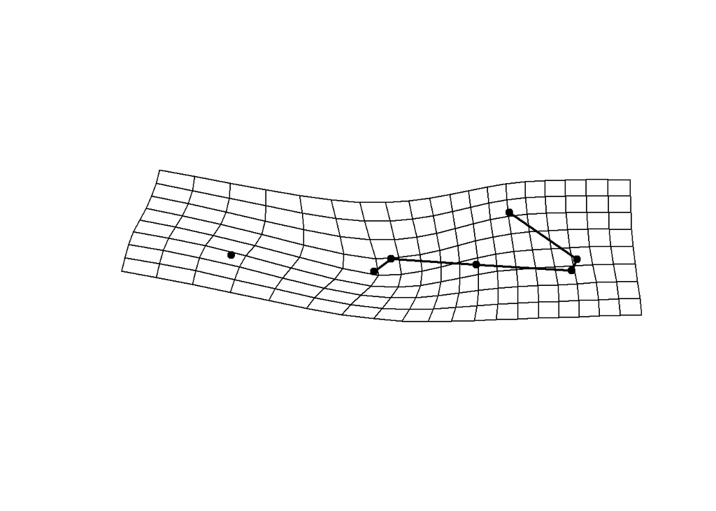

```r
#bring in links file for plotting
bee_links<-read.table('C:/Users/hrlexd/Dropbox/PlantAndFood (1)/NativeBees/Bee_pictures/Sam_april/Forewing/links_all_landmarks_remove1_sam_hind.txt',sep=',',header=F)

#nesocoletes (note average is average across all Leioproctus sp. just grouped for veiwing)
#paahua
gpl.mn<-mshape(beesgpa$coords[,,31:35])
#plotRefToTarget(M1=ref,M2=gpl.mn,mag=2)
plotRefToTarget(M1=ref,M2=gpl.mn,mag=2,links=bee_links)
```

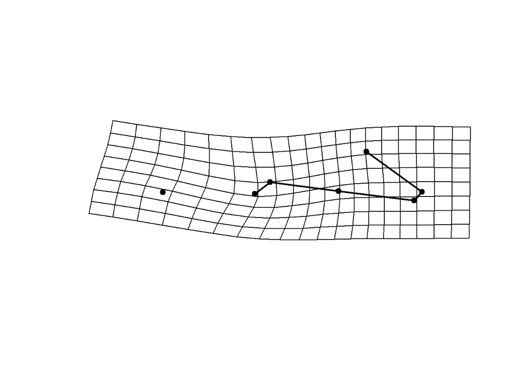

```r
#fulv
gpl.mn<-mshape(beesgpa$coords[,,c(11:15)])
#plotRefToTarget(M1=ref,M2=gpl.mn,mag=2)
plotRefToTarget(M1=ref,M2=gpl.mn,mag=2,links=bee_links)
```

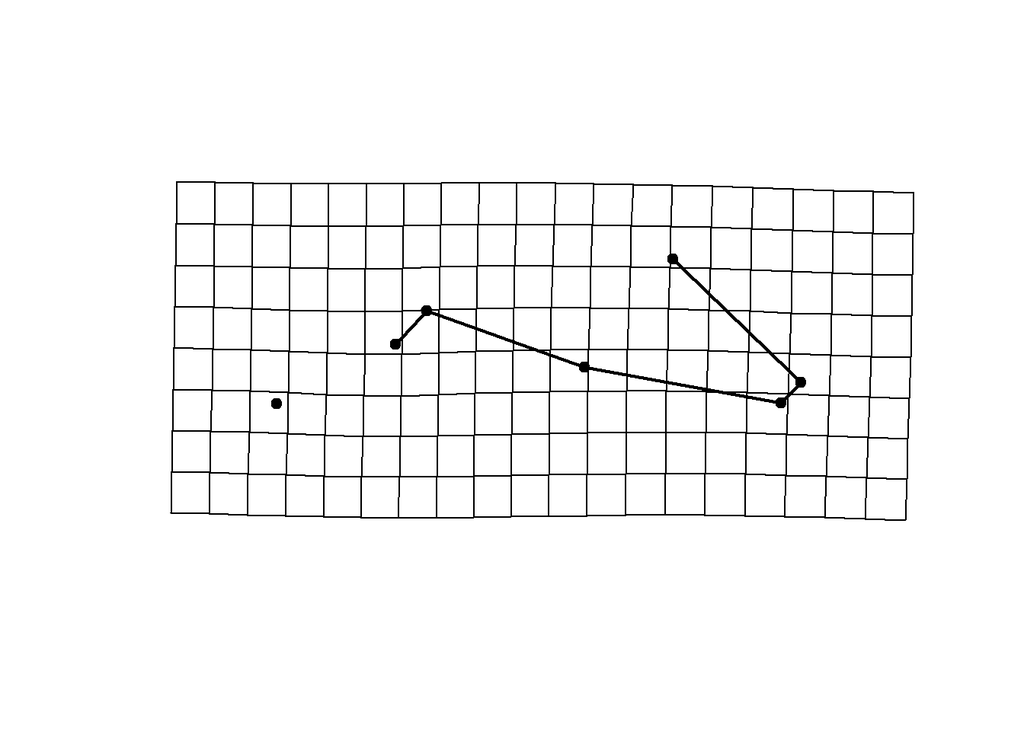

```r
#mont
gpl.mn<-mshape(beesgpa$coords[,,2:6])
#plotRefToTarget(M1=ref,M2=gpl.mn,mag=2)
plotRefToTarget(M1=ref,M2=gpl.mn,mag=2,links=bee_links)
```

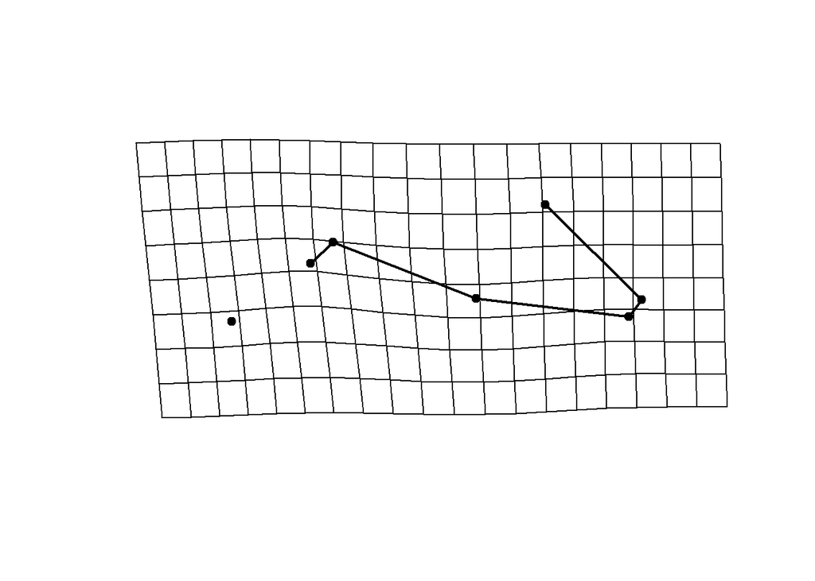

```r
#leioproctus leioproctus
#bolt
gpl.mn<-mshape(beesgpa$coords[,,c(1,7:10)])
#plotRefToTarget(M1=ref,M2=gpl.mn,mag=2)
plotRefToTarget(M1=ref,M2=gpl.mn,mag=2,links=bee_links)
```

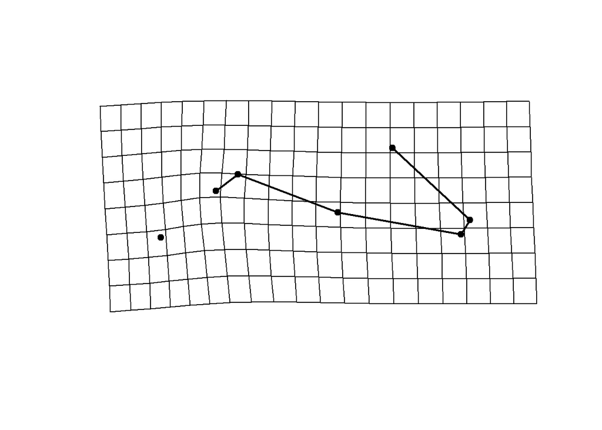

```r
#huakiwi
gpl.mn<-mshape(beesgpa$coords[,,16:20])
#plotRefToTarget(M1=ref,M2=gpl.mn,mag=2)
plotRefToTarget(M1=ref,M2=gpl.mn,mag=2,links=bee_links)
```

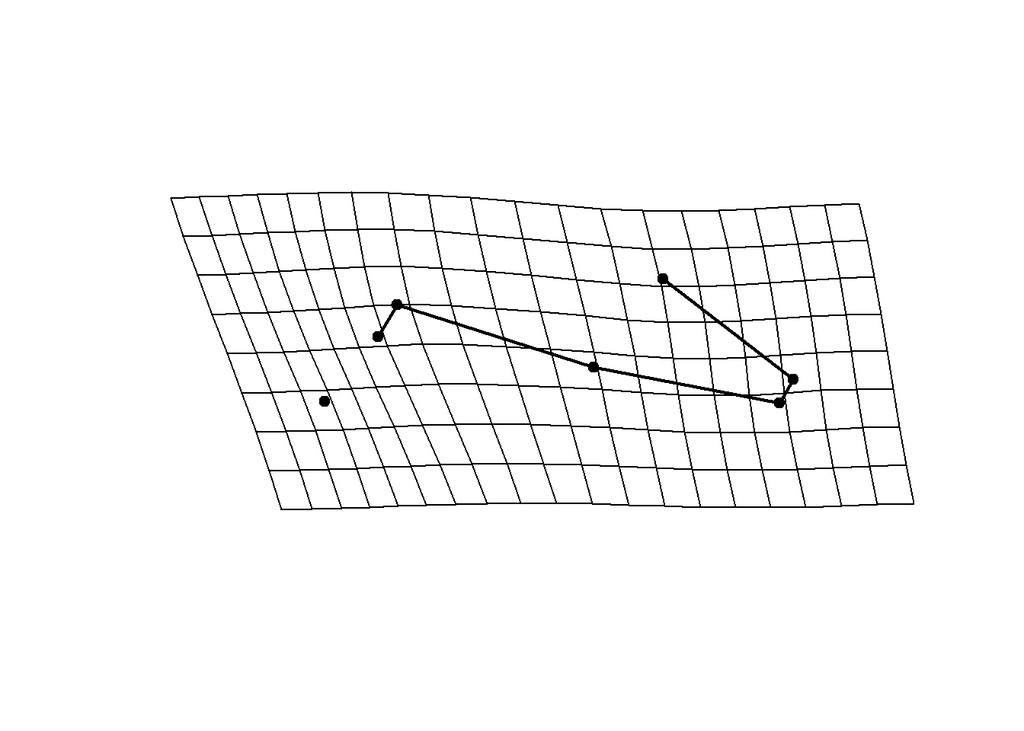

```r
#imat
gpl.mn<-mshape(beesgpa$coords[,,21:25])
#plotRefToTarget(M1=ref,M2=gpl.mn,mag=2)
plotRefToTarget(M1=ref,M2=gpl.mn,mag=2,links=bee_links)
```

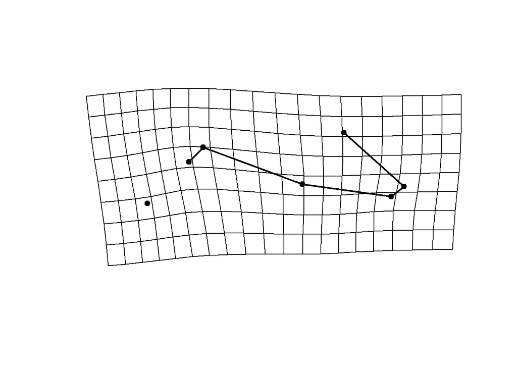

```r
#kanap
gpl.mn<-mshape(beesgpa$coords[,,26:30])
#plotRefToTarget(M1=ref,M2=gpl.mn,mag=2)
plotRefToTarget(M1=ref,M2=gpl.mn,mag=2,links=bee_links)
```

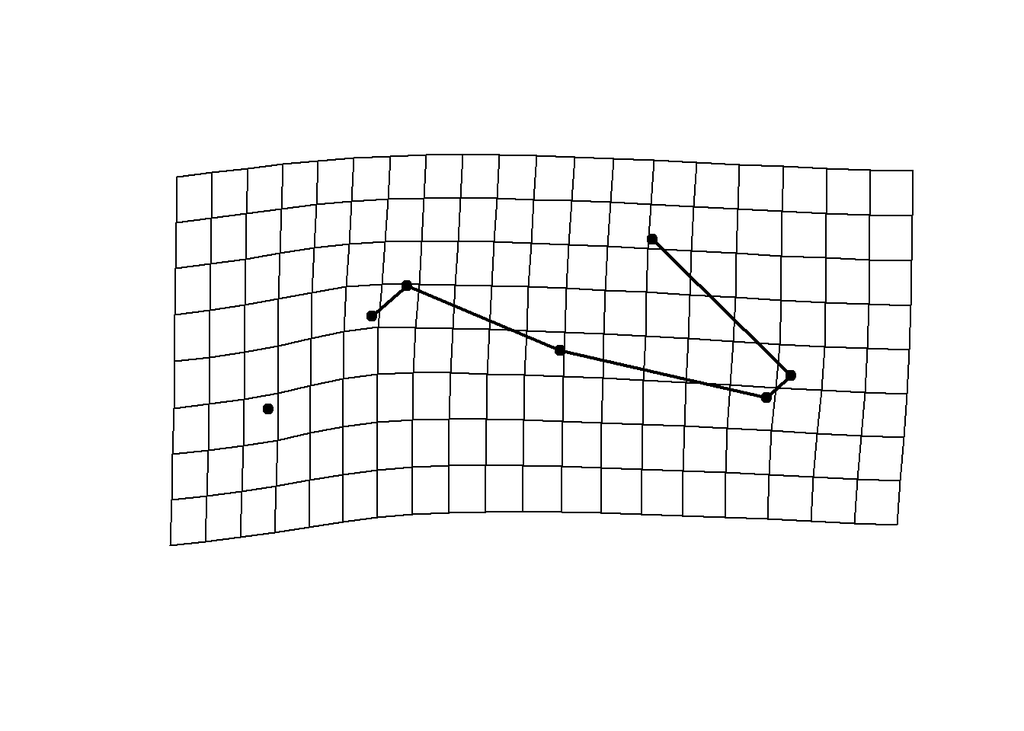

```r
#pango
gpl.mn<-mshape(beesgpa$coords[,,36:40])
#plotRefToTarget(M1=ref,M2=gpl.mn,mag=2)
plotRefToTarget(M1=ref,M2=gpl.mn,mag=2,links=bee_links)
```

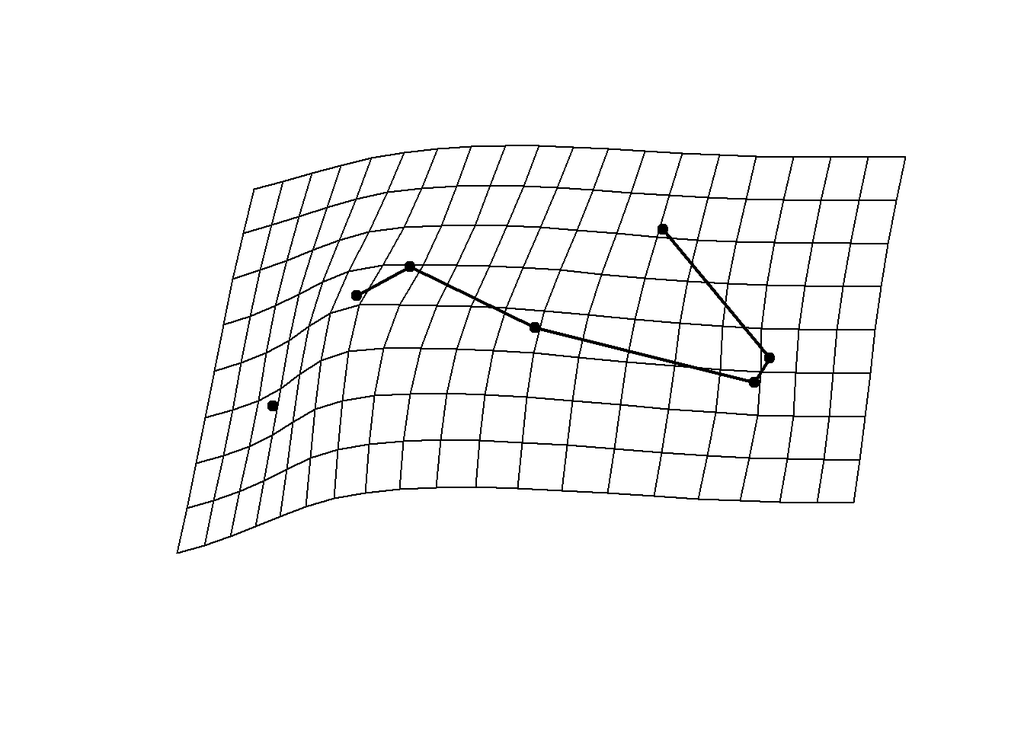

```r
#vest
gpl.mn<-mshape(beesgpa$coords[,,41:45])
#plotRefToTarget(M1=ref,M2=gpl.mn,mag=2)
plotRefToTarget(M1=ref,M2=gpl.mn,mag=2,links=bee_links)
```

```r
#
```

## Running some tests

Im not familar with geomorph so this is largely taken from the tutorial online

## Relationship between size and shape

```r
#check if there is a relationship between size and shape
#just having a look at raw csize
#size variation for hindwing
size<-as.data.frame(beesgpa$Csize)
arrange(size,desc(size$`beesgpa$Csize`)) #%>% print(n=nrow(.))
```

```
##            beesgpa$Csize
## L.fulv_4        3.383338
## L.kanap_4       3.254287
## L.kanap_1       3.228616
## L.bolt_4        3.221703
## L.paahua_2      3.212483
## L.fulv_2        3.175475
## L.kanap_2       3.170660
## L.kanap_5       3.153320
## L.paahua_1      3.152899
## L.paahua_3      3.063713
## L.huak_5        3.053777
## L.kanap_3       3.031667
## L.fulv_3        3.026351
## L.bolt_3        3.015339
## L.huak_2        3.001413
## L.bolt_1        2.976901
## L.huak_1        2.970239
## L.huak_4        2.947027
## L.paahua_5      2.944143
## L.fulv_5        2.936840
## L.bolt_5        2.931921
## L.paahua_4      2.926594
## L.bolt_2        2.910470
## L.huak_3        2.907102
## L.mont_1        2.878908
## L.pango_4       2.869911
## L.fulv_1        2.849349
## L.imat_3        2.847876
## L.imat_1        2.833997
## Vest_5          2.822990
## L.mont_5        2.800759
## L.imat_5        2.795618
## Vest_3          2.791945
## L.pango_1       2.773934
## L.imat_2        2.757308
## L.mont_3        2.754528
## L.pango_5       2.730014
## Vest_4          2.726797
## Vest_2          2.676390
## L.imat_4        2.667987
## L.mont_4        2.644619
## L.mont_2        2.633948
## L.pango_3       2.621234
## L.pango_2       2.553478
## Vest_1          2.518428
```

```r
gdf<-geomorph.data.frame(beesgpa,species=species_list)
fit.size<-procD.lm(coords~log(Csize), data = gdf, print.progress=F)
summary(fit.size)
```

```
##
## Analysis of Variance, using Residual Randomization
## Permutation procedure: Randomization of null model residuals
## Number of permutations: 1000
## Estimation method: Ordinary Least Squares
## Sums of Squares and Cross-products: Type I
## Effect sizes (Z) based on F distributions
##
##            Df       SS        MS     Rsq      F      Z Pr(>F)
## log(Csize)  1 0.028228 0.0282277 0.13383 6.6436 2.3266  0.008 **
## Residuals  43 0.182700 0.0042488 0.86617
## Total      44 0.210928
## ---
## Signif. codes:  0 '***' 0.001 '**' 0.01 '*' 0.05 '.' 0.1 ' ' 1
##
## Call: procD.lm(f1 = coords ~ log(Csize), data = gdf, print.progress = F)
```

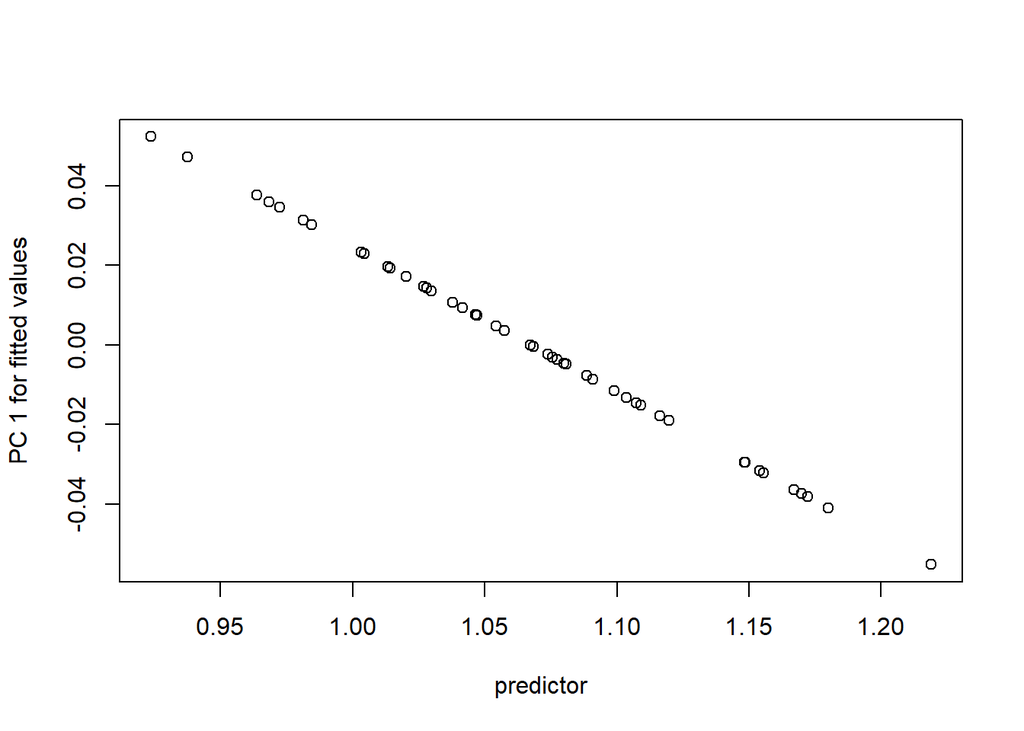

```r
#is a significant relationship between size and shape
#visiualise
#plotAllometry(fit.size,size=gdf$Csize, logsz=TRUE,method='PredLine',col=as.factor(species_list),pch=19)
#plot with legend etc
p<-plotAllometry(fit.size,size=gdf$Csize, logsz=TRUE,method='PredLine')
```

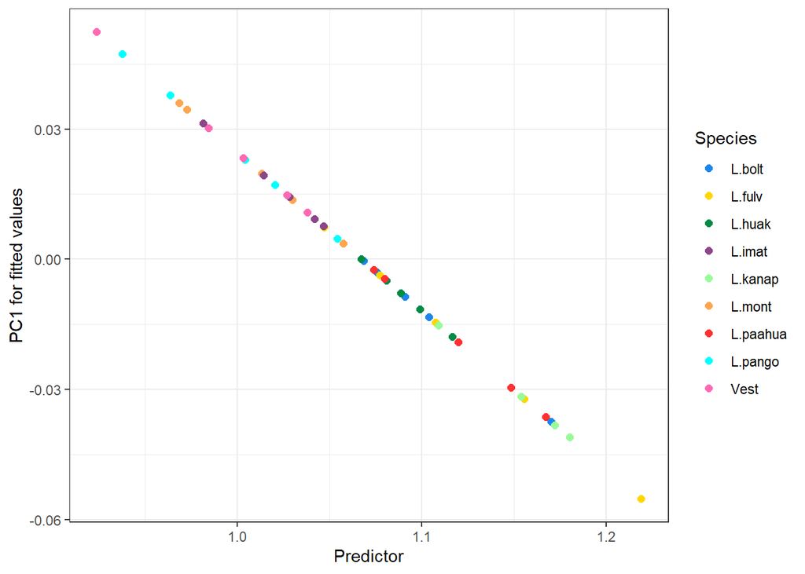

```r
p<-cbind(as.data.frame(p$plot_args$x),as.data.frame(p$plot_args$y))
names(p)[names(p) == 'p$plot_args$x'] <- 'PredLine'
names(p)[names(p) == 'p$plot_args$y'] <- 'PC1'
p<-rownames_to_column(p,var='ID')
p$bee_species<-gsub('_.*','',p$ID)

ggplot(p,aes(x=PredLine,y=PC1,colour = bee_species))+
  geom_point(size=2) +
  theme_bw()+
  scale_color_manual(values=col)+
  labs(colour='Species',x='Predictor',y='PC1 for fitted values')
```

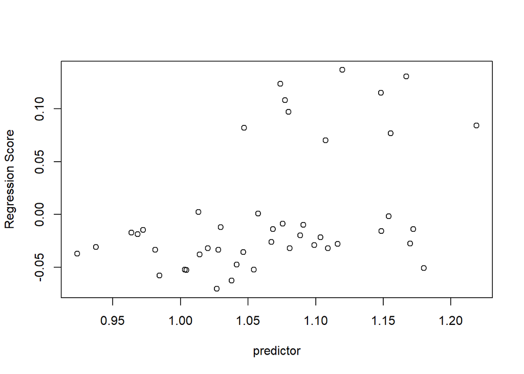

```r
#same thing here:
#plot(fit.size,type='regression',reg.type="PredLine", predictor =log(gdf$Csize))
#first principal component scores fitted values - PredLine

#regression scores-standardised regression shapes
#plotAllometry(fit.size,size=gdf$Csize, logsz=TRUE,method='RegScore',col=as.factor(species_list),pch=19)
#plot with legend etc
p<-plotAllometry(fit.size,size=gdf$Csize, logsz=TRUE,method='RegScore')
```

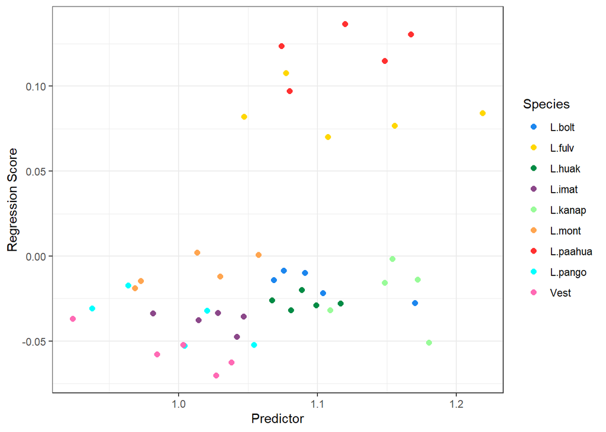

```r
p<-cbind(as.data.frame(p$plot_args$x),as.data.frame(p$plot_args$y))
names(p)[names(p) == 'p$plot_args$x'] <- 'PredLine'
names(p)[names(p) == 'V1'] <- 'RegScore'
p<-rownames_to_column(p,var='ID')
p$bee_species<-gsub('_.*','',p$ID)

ggplot(p,aes(x=PredLine,y=RegScore,colour = bee_species))+
  geom_point(size=2)+
  theme_bw()+
  scale_color_manual(values=col)+
  labs(colour='Species',x='Predictor',y='Regression Score')
```

```r
#partial least squares for relationship between shape and size
PLS<-two.b.pls(log(gdf$Csize),gdf$coords,print.progress=F)
PLS
```

```
##
## Call:
## two.b.pls(A1 = log(gdf$Csize), A2 = gdf$coords, print.progress = F)
##
##
##
## r-PLS: 0.432
##
## Effect Size (Z): 2.4023
##
## P-value: 0.005
##
## Based on 1000 random permutations
```

```r
#
```

## Relationship between size, shape and species

using Procrustes ANOVA/regression. Not convienced that I have this right and that this is the best way in regards to the posthoc pairwise tests. There is another function which I havent really explored that might be better for this.

```r
#look at the influence of shape, size and species
fit.common<-procD.lm(coords~log(Csize)+species,data=gdf)
summary(fit.common)
```

```
##
## Analysis of Variance, using Residual Randomization
## Permutation procedure: Randomization of null model residuals
## Number of permutations: 1000
## Estimation method: Ordinary Least Squares
## Sums of Squares and Cross-products: Type I
## Effect sizes (Z) based on F distributions
##
##            Df       SS        MS     Rsq      F      Z Pr(>F)
## log(Csize)  1 0.028228 0.0282277 0.13383 48.432 4.3727  0.001 ***
## species     8 0.162301 0.0202876 0.76946 34.809 8.2130  0.001 ***
## Residuals  35 0.020399 0.0005828 0.09671
## Total      44 0.210928
## ---
## Signif. codes:  0 '***' 0.001 '**' 0.01 '*' 0.05 '.' 0.1 ' ' 1
##
## Call: procD.lm(f1 = coords ~ log(Csize) + species, data = gdf)
```

```r
PW<-pairwise(fit.common,groups=species_list)
summary(PW)
```

```
##
## Pairwise comparisons
##
## Groups: L.bolt L.fulv L.huak L.imat L.kanap L.mont L.paahua L.pango Vest
##
## RRPP: 1000 permutations
##
## LS means:
## Vectors hidden (use show.vectors = TRUE to view)
##
## Pairwise distances between means, plus statistics
##                           d  UCL (95%)           Z Pr > d
## L.bolt:L.fulv    0.11481647 0.07350442  2.48616631  0.002
## L.bolt:L.huak    0.01763835 0.07127878 -1.10456770  0.854
## L.bolt:L.imat    0.04877060 0.08234162  0.62776883  0.287
## L.bolt:L.kanap   0.02017448 0.07788901 -0.88346895  0.787
## L.bolt:L.mont    0.02294817 0.08492892 -0.82692973  0.783
## L.bolt:L.paahua  0.15296165 0.07535862  3.02748447  0.001
## L.bolt:L.pango   0.04036236 0.08972913  0.15952396  0.442
## L.bolt:Vest      0.06567609 0.08852358  1.01470749  0.175
## L.fulv:L.huak    0.12134670 0.07639703  2.55519378  0.001
## L.fulv:L.imat    0.15221099 0.08730503  2.81927136  0.001
## L.fulv:L.kanap   0.12432004 0.07985982  2.50852802  0.002
## L.fulv:L.mont    0.10621982 0.08768869  1.95961155  0.020
## L.fulv:L.paahua  0.03964234 0.07497559  0.42842217  0.343
## L.fulv:L.pango   0.13590475 0.09556906  2.36637510  0.002
## L.fulv:Vest      0.15679794 0.09621417  2.64877989  0.002
## L.huak:L.imat    0.04523328 0.08099196  0.49432119  0.327
## L.huak:L.kanap   0.02773091 0.07905908 -0.35312911  0.622
## L.huak:L.mont    0.02010487 0.08753633 -1.06386567  0.849
## L.huak:L.paahua  0.16009826 0.07543282  3.09160585  0.001
## L.huak:L.pango   0.02864371 0.08767694 -0.49469247  0.681
## L.huak:Vest      0.05391235 0.08945531  0.72619751  0.248
## L.imat:L.kanap   0.03660774 0.09770308 -0.21783382  0.576
## L.imat:L.mont    0.06171782 0.07493380  1.23546434  0.128
## L.imat:L.paahua  0.19072406 0.08229877  3.42758233  0.001
## L.imat:L.pango   0.05934892 0.07869764  1.12444412  0.146
## L.imat:Vest      0.07668778 0.07580108  1.64596328  0.046
## L.kanap:L.mont   0.03654552 0.10052403 -0.32389177  0.604
## L.kanap:L.paahua 0.16263495 0.07789735  2.98620881  0.001
## L.kanap:L.pango  0.04741602 0.10274074  0.13372666  0.440
## L.kanap:Vest     0.06915103 0.10399665  0.82233129  0.210
## L.mont:L.paahua  0.14498366 0.08917764  2.62781455  0.002
## L.mont:L.pango   0.03252846 0.07256927  0.01753562  0.490
## L.mont:Vest      0.05857573 0.07525216  1.11130903  0.150
## L.paahua:L.pango 0.17432462 0.09166890  2.94717124  0.001
## L.paahua:Vest    0.19423765 0.08935188  3.29391372  0.001
## L.pango:Vest     0.03667191 0.07330398  0.27397276  0.396
```

```r
#relationship between size and species
fit1<-procD.lm(log(gdf$Csize)~species_list)
summary(fit1)
```

```
##
## Analysis of Variance, using Residual Randomization
## Permutation procedure: Randomization of null model residuals
## Number of permutations: 1000
## Estimation method: Ordinary Least Squares
## Sums of Squares and Cross-products: Type I
## Effect sizes (Z) based on F distributions
##
##              Df       SS        MS     Rsq      F      Z Pr(>F)
## species_list  8 0.151249 0.0189061 0.71196 11.123 5.5272  0.001 ***
## Residuals    36 0.061192 0.0016998 0.28804
## Total        44 0.212441
## ---
## Signif. codes:  0 '***' 0.001 '**' 0.01 '*' 0.05 '.' 0.1 ' ' 1
##
## Call: procD.lm(f1 = log(gdf$Csize) ~ species_list)
```

```r
PW<-pairwise(fit1,groups=species_list)
summary(PW)
```

```
##
## Pairwise comparisons
##
## Groups: L.bolt L.fulv L.huak L.imat L.kanap L.mont L.paahua L.pango Vest
##
## RRPP: 1000 permutations
##
## LS means:
## Vectors hidden (use show.vectors = TRUE to view)
##
## Pairwise distances between means, plus statistics
##                             d  UCL (95%)           Z Pr > d
## L.bolt:L.fulv    0.0195249742 0.08517449 -0.47896531  0.669
## L.bolt:L.huak    0.0112838810 0.08265816 -0.92046911  0.804
## L.bolt:L.imat    0.0793167422 0.08324494  1.48516258  0.066
## L.bolt:L.kanap   0.0510114900 0.08422430  0.70819985  0.263
## L.bolt:L.mont    0.0933838122 0.08612519  1.71278515  0.032
## L.bolt:L.paahua  0.0160347366 0.08752159 -0.62504151  0.727
## L.bolt:L.pango   0.1057043302 0.08397814  1.99983177  0.008
## L.bolt:Vest      0.1065421478 0.08188820  2.08867503  0.012
## L.fulv:L.huak    0.0308088552 0.08474237  0.07329180  0.486
## L.fulv:L.imat    0.0988417164 0.08463593  1.88478822  0.029
## L.fulv:L.kanap   0.0314865158 0.08185720  0.09853436  0.481
## L.fulv:L.mont    0.1129087864 0.08852617  2.05539357  0.009
## L.fulv:L.paahua  0.0034902376 0.08719731 -1.58011540  0.931
## L.fulv:L.pango   0.1252293044 0.08505548  2.35284485  0.003
## L.fulv:Vest      0.1260671220 0.08574942  2.38604931  0.002
## L.huak:L.imat    0.0680328612 0.08820474  1.13591667  0.141
## L.huak:L.kanap   0.0622953710 0.08539399  1.02029603  0.162
## L.huak:L.mont    0.0820999312 0.08464695  1.51679377  0.058
## L.huak:L.paahua  0.0273186176 0.08391371 -0.05077283  0.535
## L.huak:L.pango   0.0944204492 0.08505660  1.77956646  0.031
## L.huak:Vest      0.0952582668 0.08297334  1.86112523  0.017
## L.imat:L.kanap   0.1303282322 0.08771043  2.38728986  0.001
## L.imat:L.mont    0.0140670699 0.09124077 -0.80252823  0.777
## L.imat:L.paahua  0.0953514788 0.08543315  1.78737989  0.027
## L.imat:L.pango   0.0263875880 0.08401294 -0.14522082  0.571
## L.imat:Vest      0.0272254056 0.08652455 -0.06373008  0.522
## L.kanap:L.mont   0.1443953021 0.08682036  2.59042512  0.001
## L.kanap:L.paahua 0.0349767534 0.08209272  0.28160323  0.416
## L.kanap:L.pango  0.1567158202 0.08320114  2.80562019  0.001
## L.kanap:Vest     0.1575536378 0.08502346  2.83848379  0.001
## L.mont:L.paahua  0.1094185487 0.08850442  1.98780205  0.016
## L.mont:L.pango   0.0123205181 0.08788334 -0.84264899  0.787
## L.mont:Vest      0.0131583357 0.08465768 -0.79764808  0.760
## L.paahua:L.pango 0.1217390668 0.08526476  2.23271969  0.004
## L.paahua:Vest    0.1225768844 0.08396535  2.30652655  0.006
## L.pango:Vest     0.0008378176 0.08012312 -2.07416271  0.984
```

```r
#relationship between shape and species
fit2<-procD.lm(gdf$coords~species_list)
summary(fit2)
```

```
##
## Analysis of Variance, using Residual Randomization
## Permutation procedure: Randomization of null model residuals
## Number of permutations: 1000
## Estimation method: Ordinary Least Squares
## Sums of Squares and Cross-products: Type I
## Effect sizes (Z) based on F distributions
##
##              Df       SS        MS     Rsq      F      Z Pr(>F)
## species_list  8 0.189600 0.0237000 0.89889 40.004 8.9097  0.001 ***
## Residuals    36 0.021328 0.0005924 0.10111
## Total        44 0.210928
## ---
## Signif. codes:  0 '***' 0.001 '**' 0.01 '*' 0.05 '.' 0.1 ' ' 1
##
## Call: procD.lm(f1 = gdf$coords ~ species_list)
```

```r
PW<-pairwise(fit2,groups=species_list)
summary(PW)
```

```
##
## Pairwise comparisons
##
## Groups: L.bolt L.fulv L.huak L.imat L.kanap L.mont L.paahua L.pango Vest
##
## RRPP: 1000 permutations
##
## LS means:
## Vectors hidden (use show.vectors = TRUE to view)
##
## Pairwise distances between means, plus statistics
##                           d  UCL (95%)           Z Pr > d
## L.bolt:L.fulv    0.11320588 0.08057880  2.30101862  0.002
## L.bolt:L.huak    0.01724309 0.07725793 -1.20781187  0.874
## L.bolt:L.imat    0.04528994 0.07826286  0.55759733  0.311
## L.bolt:L.kanap   0.02384587 0.08062598 -0.59972134  0.713
## L.bolt:L.mont    0.02626120 0.08162249 -0.43737087  0.654
## L.bolt:L.paahua  0.15159927 0.07941425  2.90045704  0.001
## L.bolt:L.pango   0.03483056 0.07513791  0.07929731  0.471
## L.bolt:Vest      0.05774593 0.07611933  0.99817992  0.183
## L.fulv:L.huak    0.11877662 0.08113946  2.42343143  0.001
## L.fulv:L.imat    0.14457199 0.07790065  2.91574428  0.001
## L.fulv:L.kanap   0.12707268 0.08289345  2.46762552  0.002
## L.fulv:L.mont    0.09672662 0.07901310  2.06594530  0.012
## L.fulv:L.paahua  0.03995225 0.07773807  0.30090575  0.389
## L.fulv:L.pango   0.12498739 0.07677745  2.65053590  0.001
## L.fulv:Vest      0.14510769 0.07910594  2.97486477  0.001
## L.huak:L.imat    0.04299253 0.08210656  0.43756265  0.340
## L.huak:L.kanap   0.02983712 0.08167822 -0.24247965  0.575
## L.huak:L.mont    0.02545292 0.08164541 -0.51113306  0.669
## L.huak:L.paahua  0.15776932 0.08242479  3.03874254  0.001
## L.huak:L.pango   0.02375455 0.07582367 -0.62593235  0.715
## L.huak:Vest      0.04634474 0.07815189  0.63549659  0.261
## L.imat:L.kanap   0.03485804 0.08209487  0.02288649  0.497
## L.imat:L.mont    0.06238359 0.07989242  1.11958280  0.151
## L.imat:L.paahua  0.18307021 0.08067943  3.48906175  0.001
## L.imat:L.pango   0.05939172 0.08057989  1.00827034  0.175
## L.imat:Vest      0.07578447 0.07845696  1.53331579  0.056
## L.kanap:L.mont   0.04522322 0.08448826  0.51890158  0.319
## L.kanap:L.paahua 0.16572878 0.07900822  3.08779184  0.001
## L.kanap:L.pango  0.04613136 0.07933363  0.58306413  0.295
## L.kanap:Vest     0.06191649 0.08112617  1.14977876  0.140
## L.mont:L.paahua  0.13557245 0.07879951  2.84844618  0.001
## L.mont:L.pango   0.03143420 0.07973377 -0.17982274  0.564
## L.mont:Vest      0.05733467 0.08090099  0.97311010  0.183
## L.paahua:L.pango 0.16358426 0.08021551  3.09300451  0.001
## L.paahua:Vest    0.18283957 0.07810473  3.30079909  0.001
## L.pango:Vest     0.03661187 0.07742038  0.14814160  0.439
```

```r
#does shape differ between species, while accounting for shape co varying with size
#not convinced I have this model right, I think its an over simplification
fit3<-procD.lm(gdf$coords ~log(gdf$Csize)*species_list)
summary(fit3)
```

```
##
## Analysis of Variance, using Residual Randomization
## Permutation procedure: Randomization of null model residuals
## Number of permutations: 1000
## Estimation method: Ordinary Least Squares
## Sums of Squares and Cross-products: Type I
## Effect sizes (Z) based on F distributions
##
##                             Df       SS        MS     Rsq       F      Z Pr(>F)
## log(gdf$Csize)               1 0.028228 0.0282277 0.13383 53.4860 4.4446  0.001
## species_list                 8 0.162301 0.0202876 0.76946 38.4411 8.3833  0.001
## log(gdf$Csize):species_list  8 0.006150 0.0007687 0.02915  1.4565 1.1686  0.138
## Residuals                   27 0.014249 0.0005278 0.06756
## Total                       44 0.210928
##
## log(gdf$Csize)              ***
## species_list                ***
## log(gdf$Csize):species_list
## Residuals
## Total
## ---
## Signif. codes:  0 '***' 0.001 '**' 0.01 '*' 0.05 '.' 0.1 ' ' 1
##
## Call: procD.lm(f1 = gdf$coords ~ log(gdf$Csize) * species_list)
```

```r
#posthoc test between groups
PW<-pairwise(fit3,groups=species_list)
summary(PW)
```

```
##
## Pairwise comparisons
##
## Groups: L.bolt L.fulv L.huak L.imat L.kanap L.mont L.paahua L.pango Vest
##
## RRPP: 1000 permutations
##
## LS means:
## Vectors hidden (use show.vectors = TRUE to view)
##
## Pairwise distances between means, plus statistics
##                           d  UCL (95%)           Z Pr > d
## L.bolt:L.fulv    0.11145630 0.13253066 -0.40577292  0.649
## L.bolt:L.huak    0.02218849 0.04029048 -0.53028343  0.709
## L.bolt:L.imat    0.05943822 0.07444833  0.60159690  0.279
## L.bolt:L.kanap   0.08835651 0.06970941  2.38873101  0.021
## L.bolt:L.mont    0.02255846 0.04591775 -1.24979881  0.894
## L.bolt:L.paahua  0.13492812 0.17242408 -1.70816114  0.958
## L.bolt:L.pango   0.04891851 0.06292299  0.39327455  0.346
## L.bolt:Vest      0.08163847 0.08521475  1.17909598  0.126
## L.fulv:L.huak    0.12158847 0.14191544 -0.09015838  0.541
## L.fulv:L.imat    0.15786585 0.17680102  0.31084758  0.370
## L.fulv:L.kanap   0.15903585 0.16621465  1.43356629  0.075
## L.fulv:L.mont    0.09287500 0.12959716 -1.17794586  0.881
## L.fulv:L.paahua  0.02911422 0.06109294 -1.39174939  0.921
## L.fulv:L.pango   0.14895622 0.15850039  0.92969318  0.175
## L.fulv:Vest      0.16924476 0.17930593  0.84473614  0.203
## L.huak:L.imat    0.05479984 0.07039041  0.42181734  0.344
## L.huak:L.kanap   0.09197986 0.07142815  2.47244446  0.016
## L.huak:L.mont    0.03154580 0.04870739  0.16119859  0.441
## L.huak:L.paahua  0.14638305 0.18356195 -1.20140010  0.876
## L.huak:L.pango   0.03325733 0.05486661 -0.26791579  0.598
## L.huak:Vest      0.06658780 0.07886094  0.68080539  0.253
## L.imat:L.kanap   0.06357354 0.08174313  0.77978081  0.213
## L.imat:L.mont    0.07560602 0.08809119  0.73306354  0.233
## L.imat:L.paahua  0.18148342 0.21733363 -0.76306525  0.779
## L.imat:L.pango   0.06021082 0.08295878 -0.32278058  0.643
## L.imat:Vest      0.09407368 0.10111239  1.10759557  0.139
## L.kanap:L.mont   0.09803339 0.08072703  2.23002628  0.027
## L.kanap:L.paahua 0.18117439 0.20523150  0.69169964  0.232
## L.kanap:L.pango  0.10627622 0.08750900  2.35268552  0.023
## L.kanap:Vest     0.13628054 0.10813367  2.78797068  0.003
## L.mont:L.paahua  0.11729507 0.17131388 -2.17091485  0.987
## L.mont:L.pango   0.05839413 0.06254245  1.37083007  0.102
## L.mont:Vest      0.08672773 0.08601058  1.67033284  0.046
## L.paahua:L.pango 0.17354563 0.19878509 -0.20767340  0.578
## L.paahua:Vest    0.19143902 0.21834941 -0.36463305  0.647
## L.pango:Vest     0.04667026 0.06307922  0.22267369  0.418
```

```r
#
```

There is bunch of other functions in geomorph, including morphol.dispartiy which I havent really figured out. I need to read the guide properly and relearn some geometrics. And there is another package morpho in R which I havent looked into.

## Testing merging fore and hind wing

Just trying this out

```r
#forewing
bees_fore<-readland.tps('C:/Users/hrlexd/Dropbox/PlantAndFood (1)/NativeBees/Bee_pictures/Forewing_file_tps_dig_15_05_2025_1_renamed.TPS',specID = 'imageID')
```

```
##
## No curves detected; all points appear to be fixed landmarks.
```

```r
Sample_names<-labels(bees_fore)[[3]]
species_list<-gsub('_.*','',Sample_names)
unique(species_list)
```

```
## [1] "L.bolt"   "L.mont"   "L.fulv"   "L.huak"   "L.imat"   "L.kanap"  "L.paahua"
## [8] "L.pango"  "Vest"
```

```r
bees_fore_removefirst <- bees_fore[-1,,]
beesgpa_fore<-gpagen(bees_fore_removefirst)
```

```
##
## Performing GPA
##   |                                                                              |                                                                      |   0%  |                                                                              |==================                                       …
##
## Making projections... Finished!
```

```r
#hindwing
bees_hind<-readland.tps('C:/Users/hrlexd/Dropbox/PlantAndFood (1)/NativeBees/Bee_pictures/Hindwings_merged_cleaned_19_05_2025.TPS',specID = 'imageID')
```

```
##
## No curves detected; all points appear to be fixed landmarks.
```

```r
Sample_names<-labels(bees_hind)[[3]]
species_list<-gsub('_.*','',Sample_names)
unique(species_list)
```

```
## [1] "L.bolt"   "L.mont"   "L.fulv"   "L.huak"   "L.imat"   "L.kanap"  "L.paahua"
## [8] "L.pango"  "Vest"
```

```r
bees_hind_removefirst <- bees_hind[-1,,]
beesgpa_hind<-gpagen(bees_hind_removefirst)
```

```
##
## Performing GPA
##   |                                                                              |                                                                      |   0%  |                                                                              |==================                                       …
##
## Making projections... Finished!
```

```r
#combining
?combine.subsets
```

```
## starting httpd help server ... done
```

```r
for_lab<-labels(beesgpa_fore$coords)[[3]]
hin_lab<-labels(beesgpa_hind$coords)[[3]]
match(for_lab,hin_lab)
```

```
##  [1]  1  2  3  4  5  6  7  8  9 10 11 12 13 14 15 16 17 18 19 20 21 22 23 24 25
## [26] 26 27 28 29 30 31 32 33 34 35 36 37 38 39 40 41 42 43 44 45
```

```r
#so ordered the same
#cant find a way to keep the names during the merge but I assume they add in by raw order? Might have to check this with package authors
#seems to be an active google groups page
comb.lm <- combine.subsets(forewing= beesgpa_fore, hindwing = beesgpa_hind, gpa = TRUE)
summary(comb.lm)
```

```
##
## A total of 2 subsets were combined
##
##                              forewing  hindwing
## Number of points in subset 18.0000000 7.0000000
## Mean centroid size          4.9282647 2.9143621
## Mean relative size          0.6283946 0.3716054
```

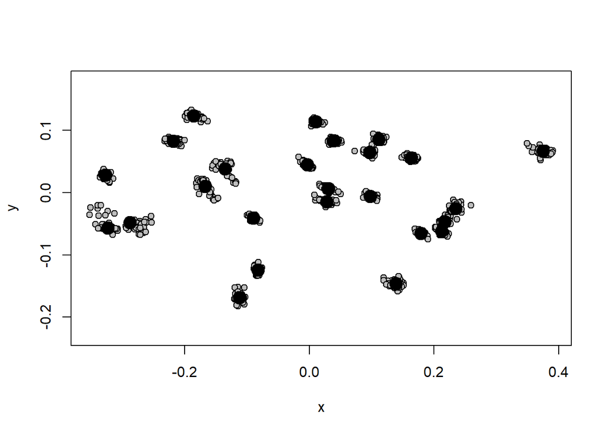

```r
#just kinda plonks them on top of each other
plotAllSpecimens(comb.lm$coords)
```

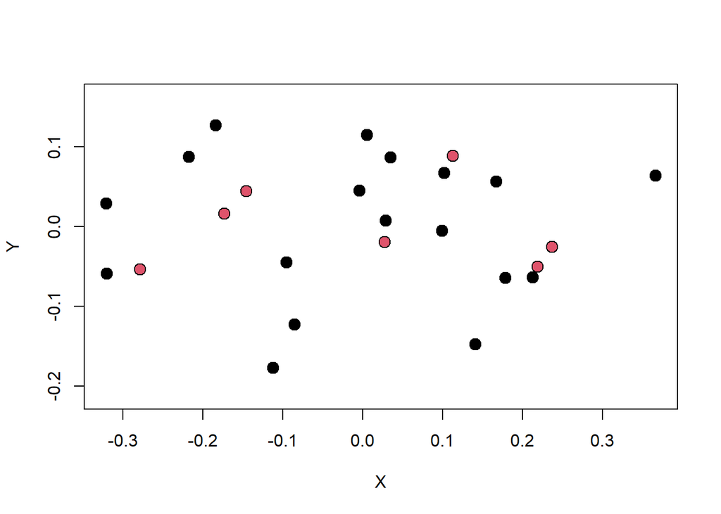

```r
#so it just plonks them on top of each other, visualised here with black and red
plot(comb.lm$coords[,,1], pch=21, bg = c(rep(1,18), rep(2,7)),asp =1,cex=1.5)
```

```r
#
```

## Stats on combined data points

Im not familiar with this approach. I found this which goes into it a bit https://github.com/DworkinLab/VirtualMorphoMeetup/blob/master/combine.subsets.talk/heads.or.tails.combined.landmarks.md and suggests reading https://faculty.sites.iastate.edu/dcadams/files/inline-files/2020-evolbiol-collyer_et_al.pdf

“We recommend that empiricists neither perform GPA on combined confgurations, nor consider combined confgurations to be organismal “shape”. Rather, combined confgurations are shape composites which can be disjoined for the purpose of shape visualisation, but used in conjuction for statistical analyses’

So we cant draw out any changes but can analyse things statistically I think

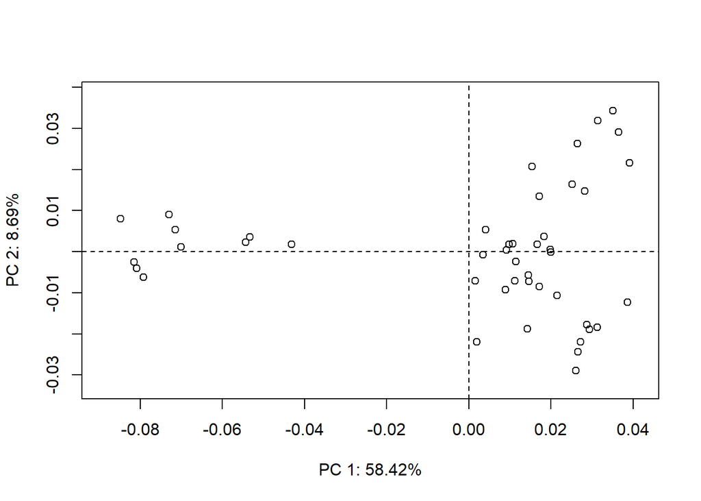

```r
#run PCA analysis
PCA<-gm.prcomp(comb.lm$coords)
#comb.lm$coords
#summary(PCA)
plot(PCA)
```

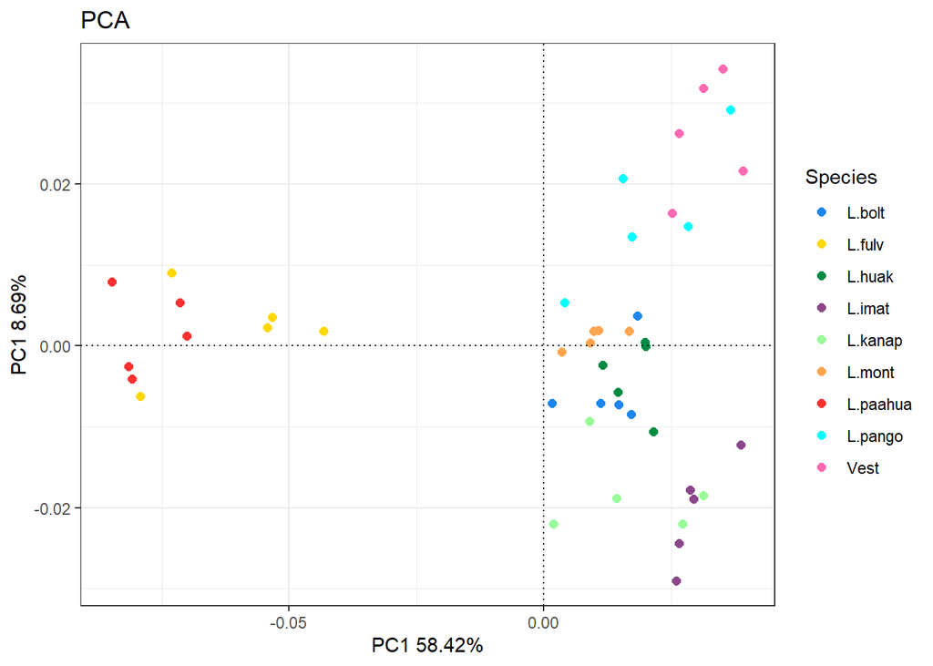

```r
#plot with legend
PCaxis<-as.data.frame(PCA$x[,1:2])
#no names in data
PCaxis$ID<-for_lab
#PCaxis<-rownames_to_column(PCaxis,var='ID')
PCaxis$bee_species<-gsub('_.*','',PCaxis$ID)

PC1_per<-round(as.data.frame(PCA$sdev^2/sum(PCA$sdev^2))[1,1]*100,digits=2)
PC2_per<-round(as.data.frame(PCA$sdev^2/sum(PCA$sdev^2))[2,1]*100,digits=2)

ggplot(PCaxis,aes(x=Comp1,y=Comp2,colour = bee_species))+
  geom_point(size=2)+
  theme_bw()+
  scale_color_manual(values=col)+
  labs(colour='Species',x=paste0('PC1 ',PC1_per,'%'),y=paste0('PC1 ',PC2_per,'%'),title="PCA")+
  geom_hline(yintercept=0, linetype='dotted', col = 'black')+
  geom_vline(xintercept=0, linetype='dotted', col = 'black')
```

```r
#
```

## Stuck

For some reason I cant generate the geomorph data frame for the stats from the combined

```r
#check if there is a relationship between size and shape
#just having a look at raw csize
#size variation for hindwing
size<-as.data.frame(comb.lm$CS)
#weird c-size came out with a name here, maybe its a bug that the coords are unnamed?
arrange(size,desc(size$forewing)) #%>% print(n=nrow(.))
```

```
##            forewing hindwing
## L.kanap_4  5.451628 3.254287
## L.bolt_4   5.401636 3.221703
## L.kanap_3  5.338963 3.031667
## L.kanap_1  5.325175 3.228616
## L.kanap_5  5.277201 3.153320
## L.bolt_1   5.251831 2.976901
## L.huak_2   5.195001 3.001413
## L.kanap_2  5.191211 3.170660
## L.huak_3   5.156144 2.907102
## L.mont_1   5.099885 2.878908
## L.bolt_2   5.094943 2.910470
## L.fulv_2   5.090562 3.175475
## L.huak_1   5.076675 2.970239
## L.huak_5   5.067888 3.053777
## L.paahua_2 5.065402 3.212483
## L.fulv_3   5.044910 3.026351
## L.bolt_3   5.031568 3.015339
## L.paahua_3 5.014506 3.063713
## L.paahua_1 5.014130 3.152899
## L.huak_4   4.998159 2.947027
## L.imat_2   4.990256 2.757308
## Vest_5     4.932109 2.822990
## L.mont_5   4.898149 2.800759
## L.fulv_4   4.896337 3.383338
## Vest_3     4.885547 2.791945
## L.mont_3   4.850969 2.754528
## L.imat_3   4.847321 2.847876
## L.paahua_4 4.836817 2.926594
## L.imat_1   4.831496 2.833997
## L.pango_5  4.818466 2.730014
## L.pango_4  4.806739 2.869911
## Vest_2     4.764802 2.676390
## L.bolt_5   4.754464 2.931921
## Vest_4     4.743233 2.726797
## L.imat_5   4.738130 2.795618
## L.pango_1  4.718574 2.773934
## L.imat_4   4.711557 2.667987
## L.mont_2   4.707089 2.633948
## L.paahua_5 4.681374 2.944143
## L.mont_4   4.663466 2.644619
## L.fulv_1   4.655944 2.849349
## L.fulv_5   4.641040 2.936840
## L.pango_2  4.456722 2.553478
## Vest_1     4.446673 2.518428
## L.pango_3  4.307219 2.621234
```

```r
#this doesnt work:
#gdf<-geomorph.data.frame(comb.lm,species=species_list)
#and even if it did I dont know how to deal with the allometry for the combined dataset as each sample has two csize values etc. So would it just be a shape ~species model
#
```